# Hyne - Logs - Green and Dry

## 2.9 Intra-Log Variation

### 2.9.1 Radial

Plot variation of moe, den, bow, crook, twist with R within individual logs

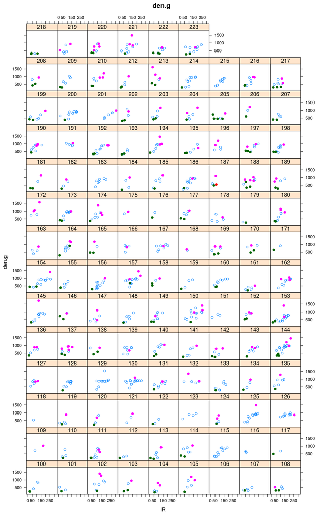

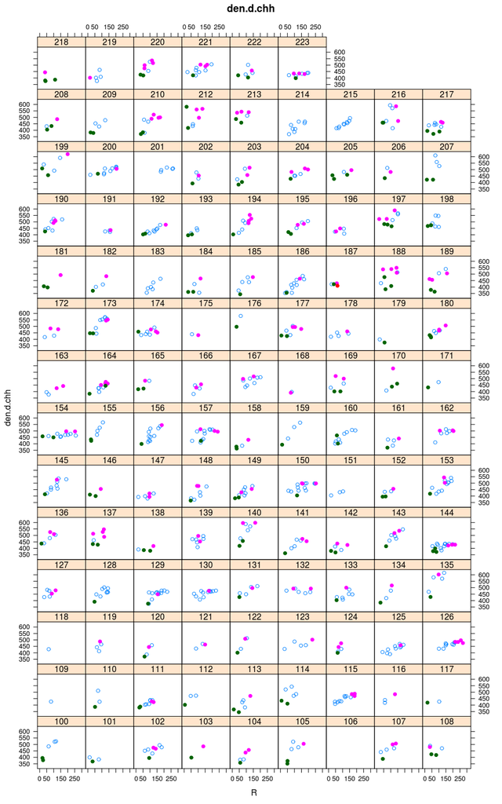

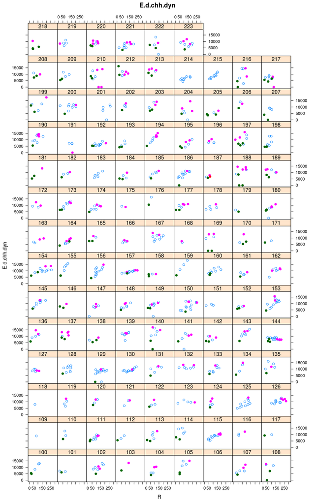

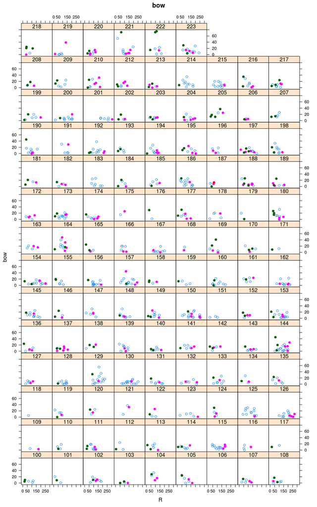

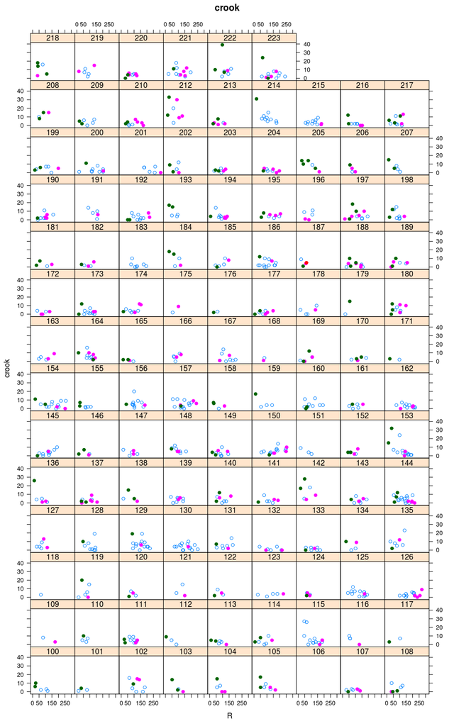

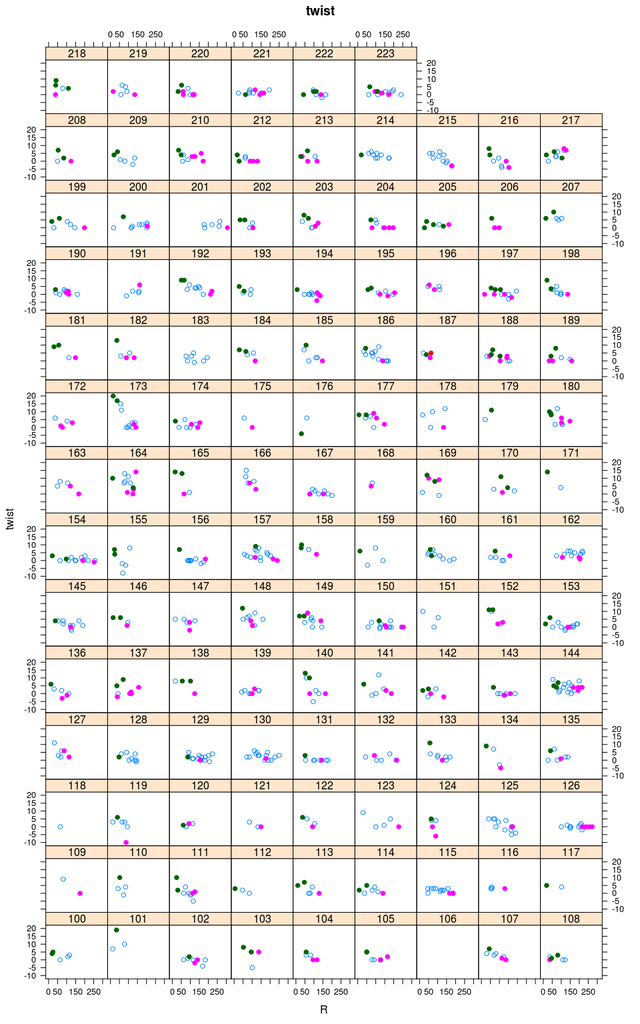

```r
for (p in c("den.g","den.d.chh","E.d.chh.dyn","bow","crook","twist")) {
  print(
    xyplot(formula(paste(p,"~ R | as.factor(SWILogNumber)")), B, group=pith_wane, pch=c(1,19,19,19), main=p)#, auto.key=TRUE)
    )
  }
```

Some very odd arrangements of pith and waney boards (e.g log 137 where a pith board has R > than a wane board!)

### 2.9.2 2D

Todo: plot moe, den, bow, crook, twist using glyph size/color/fill over individual log saw patterns

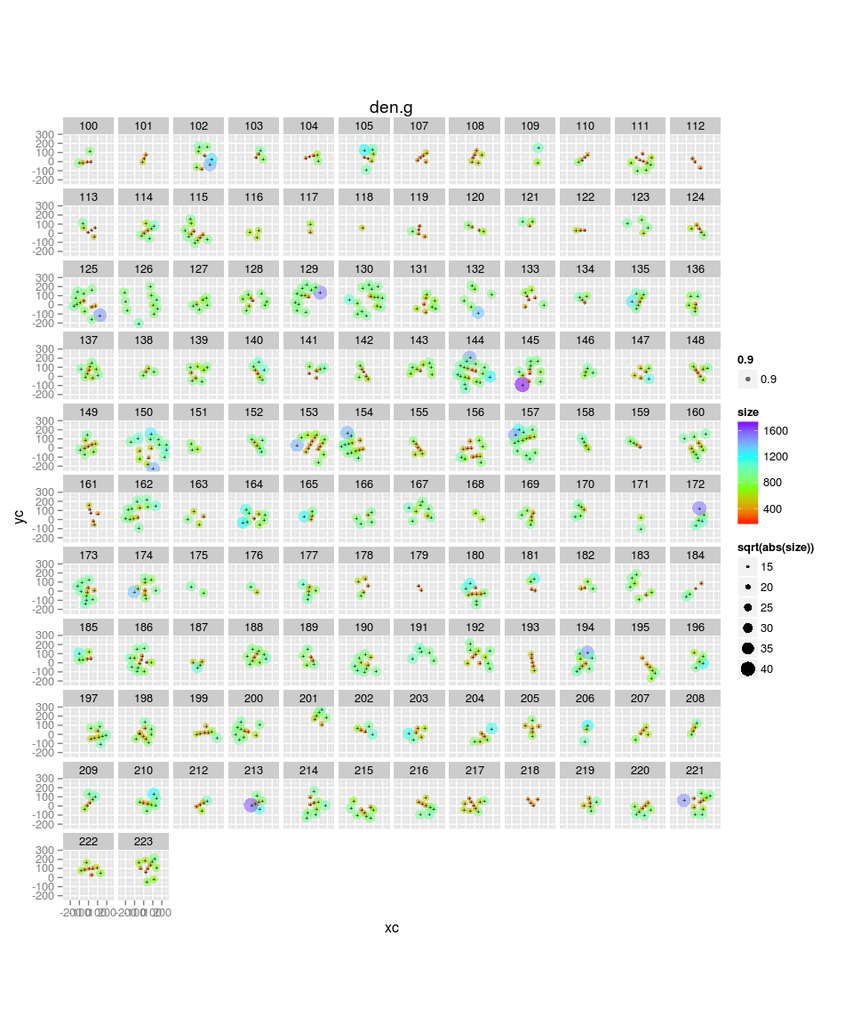

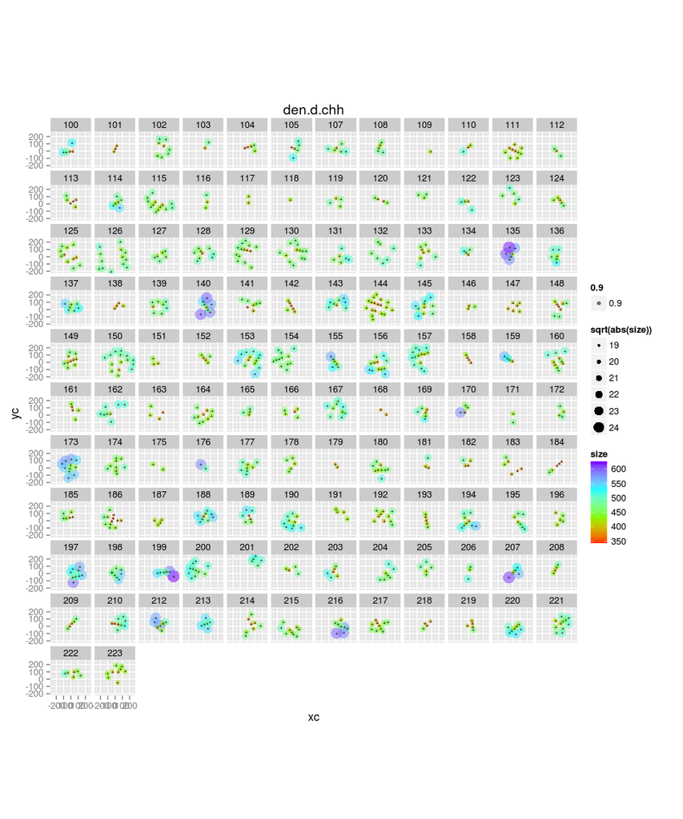

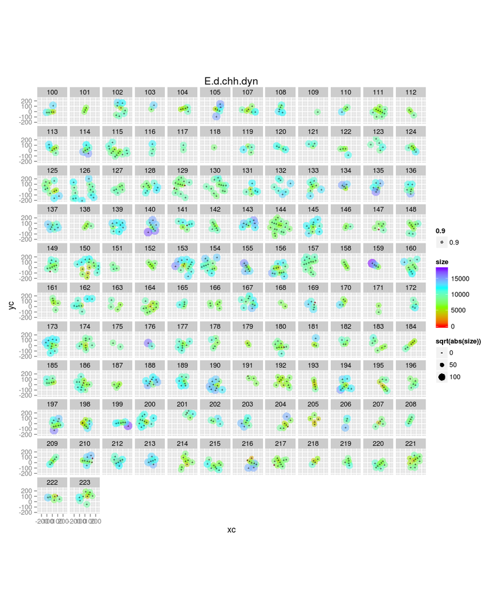

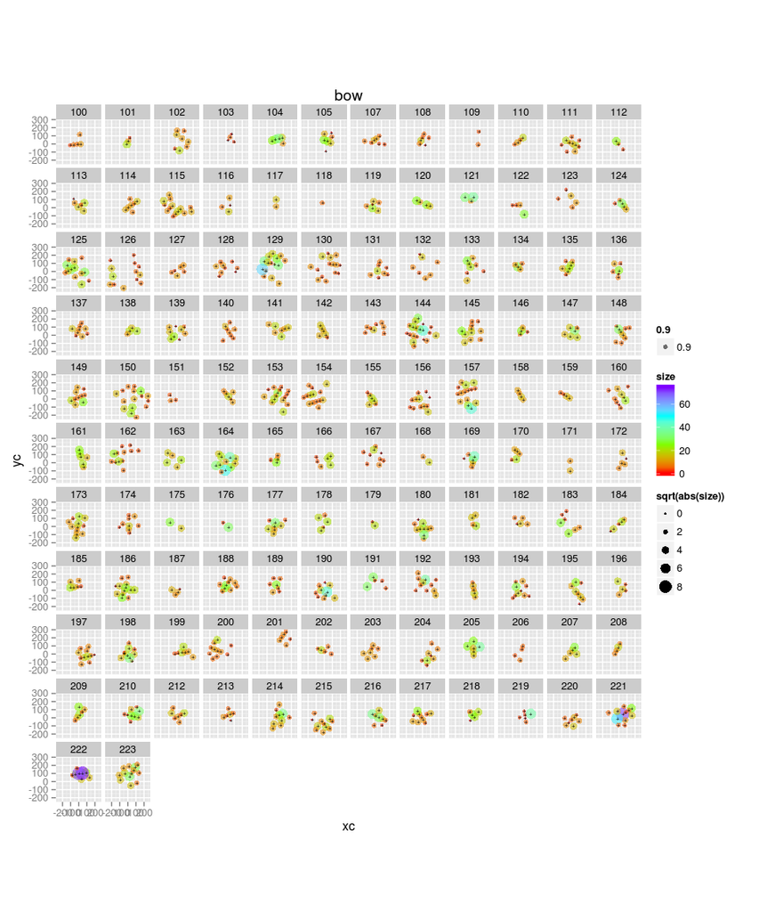

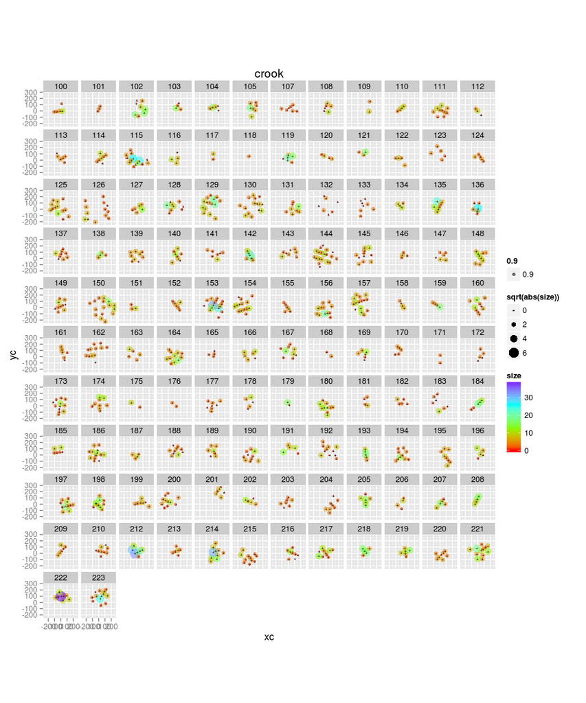

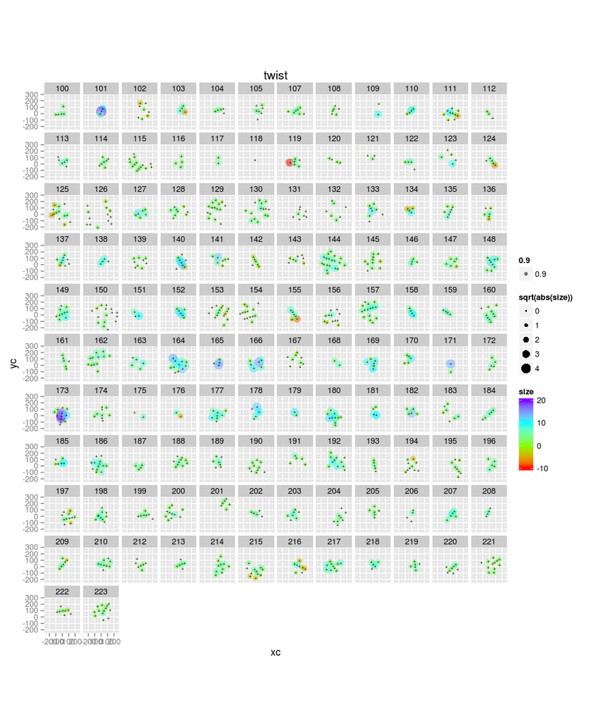

```r
ii = is.finite(B$SWILogNumber) & is.finite(B$xc) & is.finite(B$yc)
for (p in c("den.g","den.d.chh","E.d.chh.dyn","bow","crook","twist")) {
  #B$sf=B[,p]/max(B[,p])
  #xyplot(yc ~ xc | as.factor(SWILogNumber), aspect='iso', B, cex=B$sf, pch=19, subset=is.finite(p))#, cex=p)#, auto.key=TRUE)

  # try ggplot2
  B$size=B[,p]
  print(
    ggplot(B[is.finite(B$size) & ii,], aes(xc,yc))
      + geom_point(aes(size=sqrt(abs(size)),col=size,alpha=0.9))
      + geom_point(col='black', shape="+")
      + facet_wrap(~SWILogNumber)
      + coord_fixed() # achieves aspect='iso'
    + scale_colour_gradientn(colours=rainbow(4))
    + ggtitle(p)
    )
  }
```

Which logs are well represented?

Plot board positions and digitized large end information.

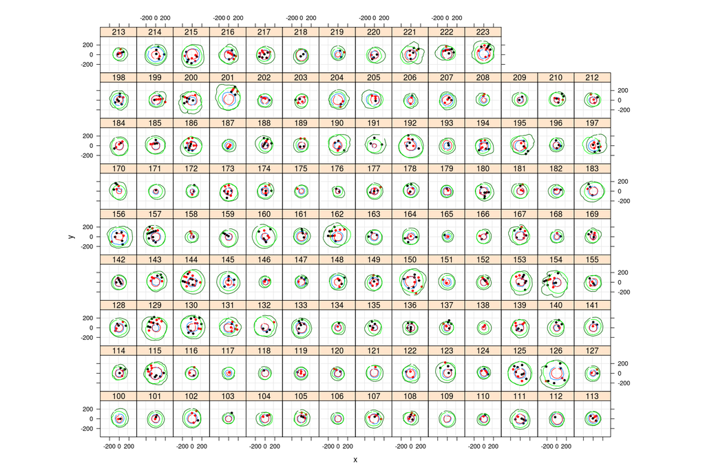

```r
xyplot(y ~ x | as.factor(SWILogNumber), group=paste(logEnd,type), D, type="l", aspect='iso',
       panel=function(x,y,subscripts,...){
          panel.grid(h=-1,y=-1)
          log = D$SWILogNumber[subscripts][1]
          ii = B$SWILogNumber==log
          panel.xyplot(B$xc[ii],B$yc[ii],pch=19,col=c('black','red')[as.numeric(B$inCant)], cex=0.5)
          panel.xyplot(x,y,subscripts=subscripts,...)
       })
```

```r
# and so after much scrutinising...
near.complete.sawpatterns = c(213,217,219,220,221,223,212,210,108,111,125,119,114,128,144,150,154,164,188,186,197)
```

How is it that some boards fall outside of the large end? e.g. 103. Do I have the rotations correct?

## 2.10 Log SWV v average Board MOE

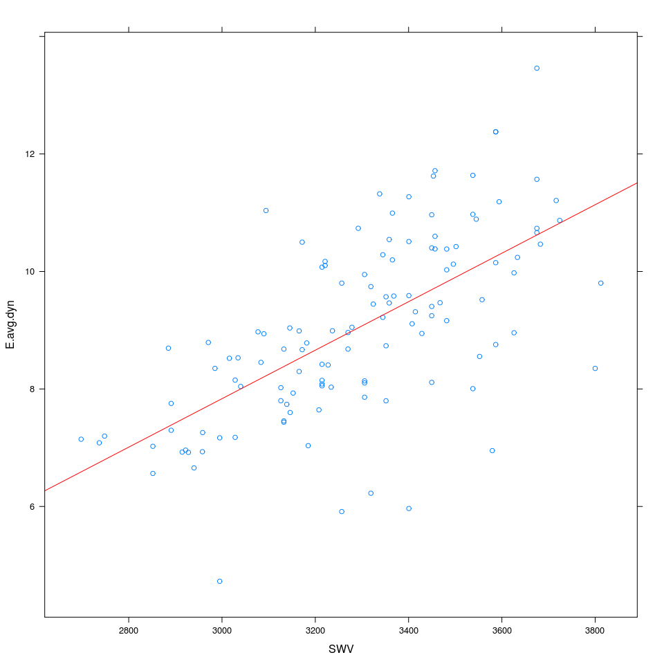

```
##
## Call:
## lm(formula = y ~ x)
##
## Residuals:
##     Min      1Q  Median      3Q     Max
## -3.5226 -0.6399  0.0464  0.7224  2.8393
##
## Coefficients:
##               Estimate Std. Error t value Pr(>|t|)
## (Intercept) -4.5446846  1.4600138  -3.113  0.00231 **
## x            0.0041265  0.0004422   9.331 6.33e-16 ***
## ---
## Signif. codes:  0 '***' 0.001 '**' 0.01 '*' 0.05 '.' 0.1 ' ' 1
##
## Residual standard error: 1.196 on 121 degrees of freedom
## Multiple R-squared:  0.4184, Adjusted R-squared:  0.4136
## F-statistic: 87.06 on 1 and 121 DF,  p-value: 6.332e-16
```

```r
mypanel=function(x,y,...){
  #panel.abline(c(0,1), col='grey70', lty=2)
  panel.xyplot(x,y,...)
  m=lm(y ~ x)
  print(summary(m))
  panel.abline(coef(m),col='red')
}
#xyplot(E.avg ~ SWV, L, panel=mypanel) # hitman in yard
#xyplot(E.avg ~ velocity, L, subset=velocity>0, panel=mypanel) # calibre log tool
xyplot(E.avg.dyn ~ SWV, L, panel=mypanel) # hitman in yard
```

```r
#xyplot(E.avg.dyn ~ velocity, L, subset=velocity>0, panel=mypanel) # calibre log tool
```

Ugly.

## 2.11 Warp

### 2.11.1 Per Log Distributions

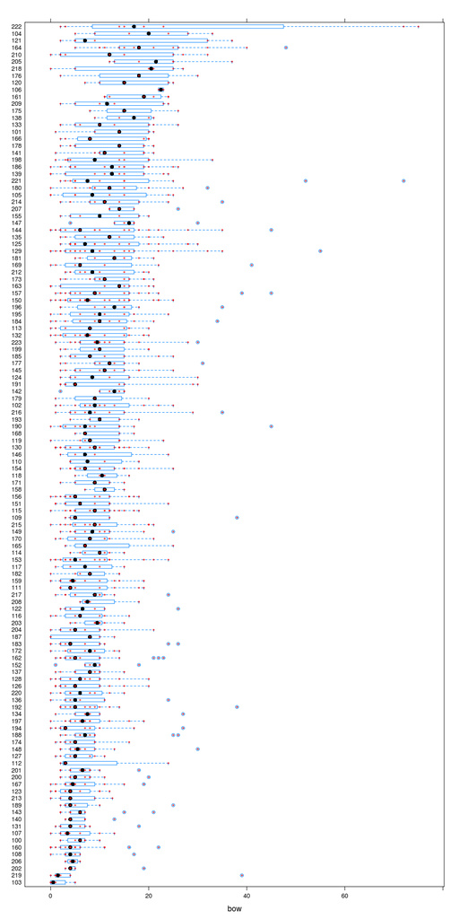

```r
bwpanel=function(...){
          panel.bwplot(...)
          panel.points(...,col='red', cex=0.3)
        }
bwplot( factor(SWILogNumber,levels=L$SWILogNumber[order(L$bow_p75)],ordered=TRUE) ~ bow, B, panel=bwpanel)
```

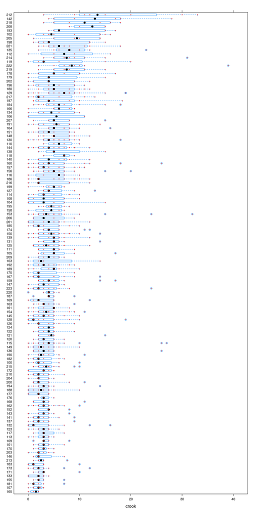

```r
bwplot( factor(SWILogNumber,levels=L$SWILogNumber[order(L$crook_p75)],ordered=TRUE) ~ crook, B, panel=bwpanel)
```

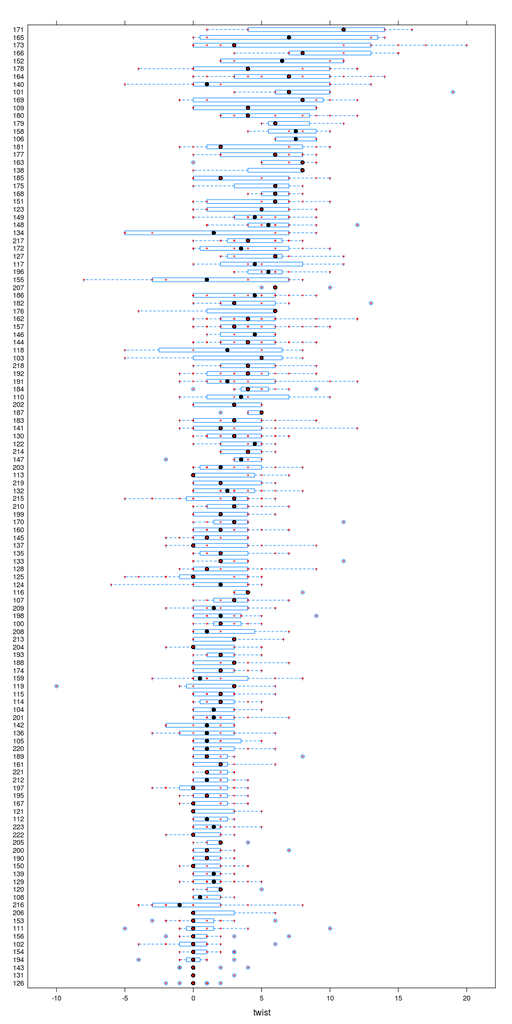

```r
bwplot( factor(SWILogNumber,levels=L$SWILogNumber[order(L$twist_p75)],ordered=TRUE) ~ twist, B, panel=bwpanel)
```

### 2.11.2 Correlations

#### 2.11.2.1 Between Log Quality Measures

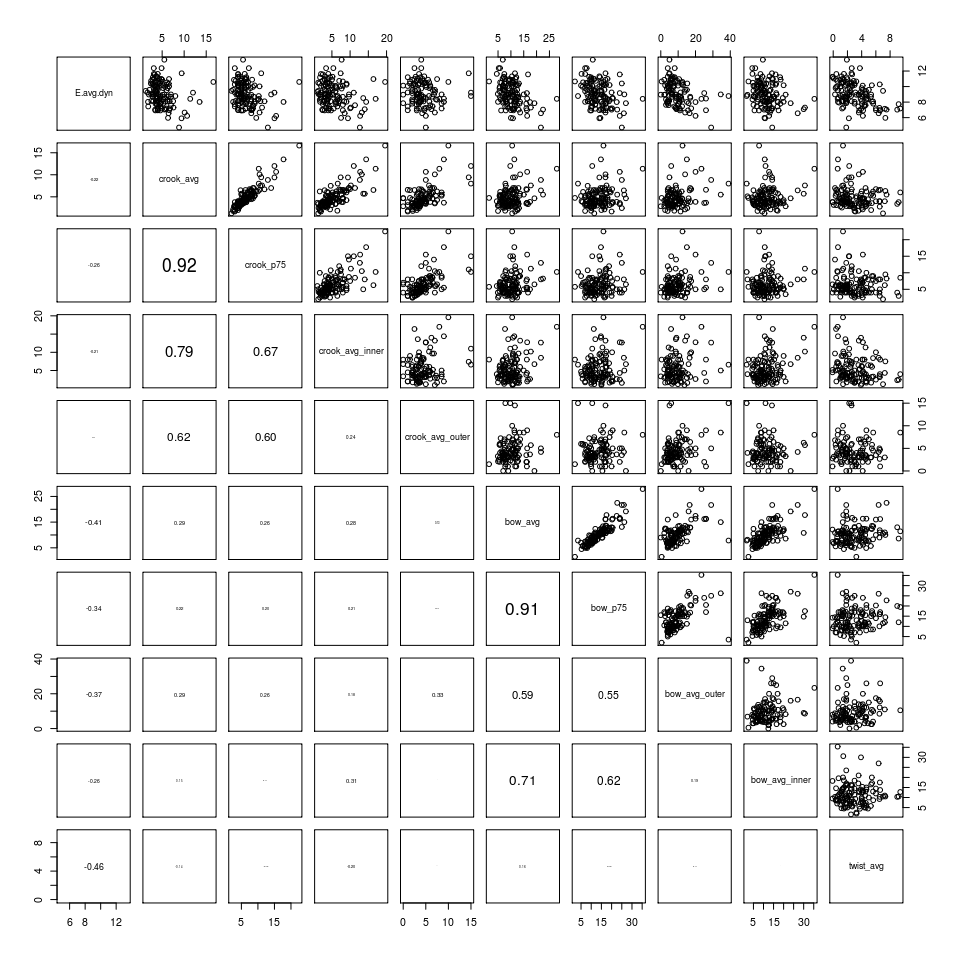

```r
log.quality.measures = c("E.avg.dyn",
                         "crook_avg","crook_p75","crook_avg_inner","crook_avg_outer",
                         "bow_avg","bow_p75","bow_avg_outer","bow_avg_inner",
                         "twist_avg")
pairs(L[,log.quality.measures],
      lower.panel=function(x,y,...) {
        usr <- par("usr"); on.exit(par(usr))
        par(usr = c(0, 1, 0, 1))
        ii=is.finite(x) & is.finite(y)
        r <- cor(x[ii], y[ii])
        txt <- format(c(r, 0.123456789), digits = 2)[1]
        #txt <- paste0("r=", txt)
        #cex.cor <- 0.8/strwidth(txt)
        text(0.5, 0.5, txt, cex = 1.8 * abs(r))
})
```

Average and 75th percentile bow and crook strongly correlated. Consider only average from here on.

#### 2.11.2.2 Log Q vs Predictors

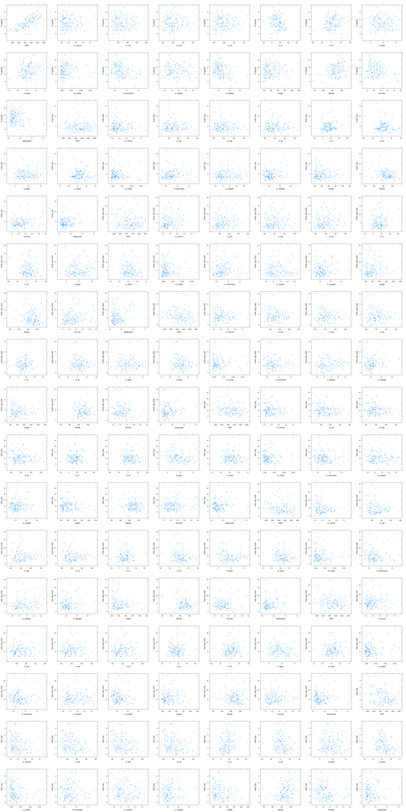

```r
log.quality.measures = c("E.avg.dyn",
                         "crook_avg","crook_avg_inner","crook_avg_outer",
                         "bow_avg","bow_avg_outer","bow_avg_inner",
                         "twist_avg")
plots <- list()
for (l in log.quality.measures) {
  for (p in predictors) {
    plots <- c(plots, list(xyplot(L[,l] ~ L[,p], xlab=p, ylab=l)))
  }
}
do.call(grid.arrange, c(plots, nrow=length(predictors)))
```

Twist turns out to be surprisingly predictable (see below). Is this due to correlation with stiffness?

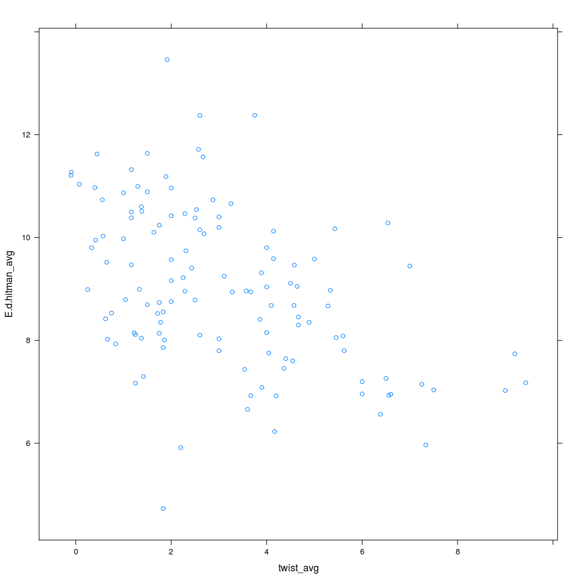

```r
xyplot(E.d.hitman_avg ~ twist_avg, L)
```

```r
summary(lm(E.d.hitman_avg ~ twist_avg, L))
```

```
##
## Call:
## lm(formula = E.d.hitman_avg ~ twist_avg, data = L)
##
## Residuals:
##     Min      1Q  Median      3Q     Max
## -4.7408 -0.9521 -0.0143  0.9708  4.0205
##
## Coefficients:
##             Estimate Std. Error t value Pr(>|t|)
## (Intercept) 10.09563    0.22422  45.026  < 2e-16 ***
## twist_avg   -0.34252    0.06032  -5.679  9.5e-08 ***
## ---
## Signif. codes:  0 '***' 0.001 '**' 0.01 '*' 0.05 '.' 0.1 ' ' 1
##
## Residual standard error: 1.394 on 121 degrees of freedom
## Multiple R-squared:  0.2104, Adjusted R-squared:  0.2039
## F-statistic: 32.25 on 1 and 121 DF,  p-value: 9.503e-08
```

### 2.11.3 Cant v Edge Boards

> - Is a stiffness segregation device required on the edger? i.e. what % of lumber that is not from the cant has stiffness below 6GPa? If this is a major lets drop it.

Cant boards manually identified with the help of ‘assign_inCant.R’.

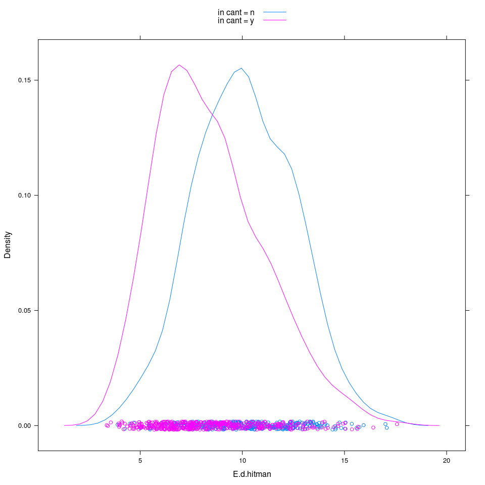

```r
densityplot(~E.d.hitman, group=paste("in cant =",inCant), B[!is.na(B$inCant),], auto.key=TRUE)
```

Unsurprisingly, side boards (‘inCant=n’) have a higher average stiffness than cant boards (‘inCant=y’)

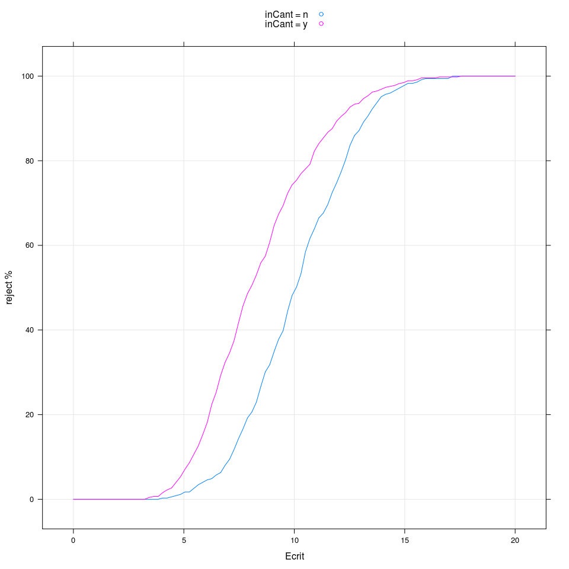

```r
'%==%' <- function(a, b) !is.na(a) & !is.na(b) & a==b;
'%<%' <- function(a, b) !is.na(a) & !is.na(b) & a<b;
reject.frac = data.frame()
for (Ecrit in seq(0,20,length.out=100)) {
  for (inCant in c('n','y')) {
      nrej = sum(B$E.d.hitman%<%Ecrit&B$inCant%==%inCant)
      ntot = sum(!is.na(B$E.d.hitman)&B$inCant%==%inCant)
      reject.frac = rbind(reject.frac,
                        data.frame(inCant=inCant,Ecrit=Ecrit,frac=nrej/ntot))
  }
}
xyplot(frac*100 ~ Ecrit, group=paste("inCant =",inCant), reject.frac, type='l', auto.key=TRUE, ylab="reject %", panel=function(...){
  panel.grid(h=-1,v=-1)
  panel.xyplot(...)
})
```

# 3 Modelling

## 3.1 Stiffness

Find the best linear model for log average MOE.

```r
summary(m <- lm(E.avg.dyn ~ (m_volume+SWV+m_led+m_sed+m_a0+m_a1+m_a2+m_taper+m_waist+m_ovality+m_whorliness+m_sweep1+m_sweep2+weight+hw.vfrac), L, subset=!is.na(L$m_sed)))
```

```
##
## Call:
## lm(formula = E.avg.dyn ~ (m_volume + SWV + m_led + m_sed + m_a0 +
##     m_a1 + m_a2 + m_taper + m_waist + m_ovality + m_whorliness +
##     m_sweep1 + m_sweep2 + weight + hw.vfrac), data = L, subset = !is.na(L$m_sed))
##
## Residuals:
##     Min      1Q  Median      3Q     Max
## -3.4840 -0.4265 -0.0343  0.4913  1.7277
##
## Coefficients:
##                Estimate Std. Error t value Pr(>|t|)
## (Intercept)  -4.835e+00  1.958e+00  -2.469   0.0151 *
## m_volume     -3.814e+00  5.619e+00  -0.679   0.4988
## SWV           4.965e-03  3.797e-04  13.075  < 2e-16 ***
## m_led         3.753e-02  2.625e-02   1.430   0.1558
## m_sed         9.822e-03  1.422e-02   0.691   0.4913
## m_a0         -5.402e-02  3.274e-02  -1.650   0.1019
## m_a1          1.065e-01  9.377e-02   1.135   0.2587
## m_a2         -2.104e-02  1.017e-01  -0.207   0.8365
## m_taper      -6.958e-01  4.518e-01  -1.540   0.1265
## m_waist       1.257e+01  5.238e+00   2.399   0.0181 *
## m_ovality     4.784e+01  1.109e+02   0.431   0.6671
## m_whorliness -6.084e-01  3.334e-01  -1.825   0.0708 .
## m_sweep1      1.814e-01  1.404e-01   1.292   0.1991
## m_sweep2     -1.354e+00  8.082e-01  -1.675   0.0968 .
## weight        7.223e-03  4.573e-03   1.580   0.1171
## hw.vfrac     -5.500e+00  1.213e+00  -4.534 1.51e-05 ***
## ---
## Signif. codes:  0 '***' 0.001 '**' 0.01 '*' 0.05 '.' 0.1 ' ' 1
##
## Residual standard error: 0.8278 on 107 degrees of freedom
## Multiple R-squared:  0.7538, Adjusted R-squared:  0.7193
## F-statistic: 21.84 on 15 and 107 DF,  p-value: < 2.2e-16
```

```r
summary(m.best <- step(m, direction="both"))
```

```
## Start:  AIC=-31.62
## E.avg.dyn ~ (m_volume + SWV + m_led + m_sed + m_a0 + m_a1 + m_a2 +
##     m_taper + m_waist + m_ovality + m_whorliness + m_sweep1 +
##     m_sweep2 + weight + hw.vfrac)
##
##                Df Sum of Sq     RSS     AIC
## - m_a2          1     0.029  73.355 -33.575
## - m_ovality     1     0.127  73.454 -33.410
## - m_volume      1     0.316  73.642 -33.096
## - m_sed         1     0.327  73.653 -33.077
## - m_a1          1     0.883  74.210 -32.151
## - m_sweep1      1     1.144  74.470 -31.720
## <none>                       73.326 -31.624
## - m_led         1     1.400  74.726 -31.297
## - m_taper       1     1.626  74.952 -30.927
## - weight        1     1.710  75.036 -30.789
## - m_a0          1     1.866  75.192 -30.533
## - m_sweep2      1     1.923  75.249 -30.439
## - m_whorliness  1     2.282  75.608 -29.855
## - m_waist       1     3.945  77.271 -27.178
## - hw.vfrac      1    14.089  87.415 -12.006
## - SWV           1   117.154 190.480  83.796
##
## Step:  AIC=-33.57
## E.avg.dyn ~ m_volume + SWV + m_led + m_sed + m_a0 + m_a1 + m_taper +
##     m_waist + m_ovality + m_whorliness + m_sweep1 + m_sweep2 +
##     weight + hw.vfrac
##
##                Df Sum of Sq     RSS     AIC
## - m_ovality     1     0.126  73.482 -35.363
## - m_sed         1     0.365  73.721 -34.964
## - m_volume      1     1.030  74.385 -33.860
## - m_sweep1      1     1.116  74.472 -33.717
## <none>                       73.355 -33.575
## - m_led         1     1.413  74.768 -33.228
## - m_a0          1     1.855  75.211 -32.503
## - m_sweep2      1     1.902  75.257 -32.427
## - m_whorliness  1     2.300  75.655 -31.778
## + m_a2          1     0.029  73.326 -31.624
## - weight        1     2.835  76.191 -30.910
```

[output cut: 56 more lines]

```
## - m_sweep1      1     1.238  76.257 -36.804
## - m_led         1     1.293  76.311 -36.716
## + m_volume      1     1.139  73.879 -36.699
## + m_a2          1     0.928  74.090 -36.349
## - m_sweep2      1     1.794  76.812 -35.911
## - m_a0          1     1.823  76.842 -35.864
## + m_sed         1     0.529  74.489 -35.689
## - weight        1     1.946  76.964 -35.668
## + m_ovality     1     0.137  74.882 -35.042
## - m_whorliness  1     2.944  77.962 -34.084
## - m_a1          1     3.535  78.553 -33.154
## - m_waist       1     4.188  79.206 -32.136
## - m_taper       1     5.270  80.288 -30.467
## - hw.vfrac      1    23.134  98.152  -5.756
## - SWV           1   121.581 196.599  79.685
```

```
##
## Call:
## lm(formula = E.avg.dyn ~ SWV + m_led + m_a0 + m_a1 + m_taper +
##     m_waist + m_whorliness + m_sweep1 + m_sweep2 + weight + hw.vfrac,
##     data = L, subset = !is.na(L$m_sed))
##
## Residuals:
##     Min      1Q  Median      3Q     Max
## -3.6616 -0.3750 -0.0511  0.5017  1.6243
##
## Coefficients:
##                Estimate Std. Error t value Pr(>|t|)
## (Intercept)  -4.3712770  1.7539168  -2.492  0.01417 *
## SWV           0.0050099  0.0003735  13.413  < 2e-16 ***
## m_led         0.0358645  0.0259284   1.383  0.16938
## m_a0         -0.0459245  0.0279586  -1.643  0.10330
## m_a1          0.1162266  0.0508187   2.287  0.02409 *
## m_taper      -0.7343405  0.2629693  -2.792  0.00616 **
## m_waist      11.5402313  4.6357006   2.489  0.01428 *
## m_whorliness -0.6522707  0.3125403  -2.087  0.03918 *
## m_sweep1      0.1841004  0.1359972   1.354  0.17858
## m_sweep2     -1.2690052  0.7787996  -1.629  0.10606
## weight        0.0048431  0.0028539   1.697  0.09250 .
## hw.vfrac     -5.9220943  1.0122030  -5.851 5.03e-08 ***
## ---
## Signif. codes:  0 '***' 0.001 '**' 0.01 '*' 0.05 '.' 0.1 ' ' 1
##
## Residual standard error: 0.8221 on 111 degrees of freedom
## Multiple R-squared:  0.7481, Adjusted R-squared:  0.7231
## F-statistic: 29.97 on 11 and 111 DF,  p-value: < 2.2e-16
```

```r
m.best$anova
```

```
##          Step Df   Deviance Resid. Df Resid. Dev       AIC
## 1             NA         NA       107   73.32606 -31.62400
## 2      - m_a2  1 0.02932643       108   73.35538 -33.57482
## 3 - m_ovality  1 0.12634602       109   73.48173 -35.36315
## 4     - m_sed  1 0.39771212       110   73.87944 -36.69922
## 5  - m_volume  1 1.13863463       111   75.01808 -36.81800
```

```r
m.best <- step(m, direction="backward")
```

```
## Start:  AIC=-31.62
## E.avg.dyn ~ (m_volume + SWV + m_led + m_sed + m_a0 + m_a1 + m_a2 +
##     m_taper + m_waist + m_ovality + m_whorliness + m_sweep1 +
##     m_sweep2 + weight + hw.vfrac)
##
##                Df Sum of Sq     RSS     AIC
## - m_a2          1     0.029  73.355 -33.575
## - m_ovality     1     0.127  73.454 -33.410
## - m_volume      1     0.316  73.642 -33.096
## - m_sed         1     0.327  73.653 -33.077
## - m_a1          1     0.883  74.210 -32.151
## - m_sweep1      1     1.144  74.470 -31.720
## <none>                       73.326 -31.624
## - m_led         1     1.400  74.726 -31.297
## - m_taper       1     1.626  74.952 -30.927
## - weight        1     1.710  75.036 -30.789
## - m_a0          1     1.866  75.192 -30.533
## - m_sweep2      1     1.923  75.249 -30.439
## - m_whorliness  1     2.282  75.608 -29.855
## - m_waist       1     3.945  77.271 -27.178
## - hw.vfrac      1    14.089  87.415 -12.006
## - SWV           1   117.154 190.480  83.796
##
## Step:  AIC=-33.57
## E.avg.dyn ~ m_volume + SWV + m_led + m_sed + m_a0 + m_a1 + m_taper +
##     m_waist + m_ovality + m_whorliness + m_sweep1 + m_sweep2 +
##     weight + hw.vfrac
##
##                Df Sum of Sq     RSS     AIC
## - m_ovality     1     0.126  73.482 -35.363
## - m_sed         1     0.365  73.721 -34.964
## - m_volume      1     1.030  74.385 -33.860
## - m_sweep1      1     1.116  74.472 -33.717
## <none>                       73.355 -33.575
## - m_led         1     1.413  74.768 -33.228
## - m_a0          1     1.855  75.211 -32.503
## - m_sweep2      1     1.902  75.257 -32.427
## - m_whorliness  1     2.300  75.655 -31.778
## - weight        1     2.835  76.191 -30.910
## - m_a1          1     3.768  77.124 -29.413
```

[output cut: 46 more lines]

```
##     m_sweep1 + m_sweep2 + weight + hw.vfrac
##
##                Df Sum of Sq     RSS     AIC
## <none>                       75.018 -36.818
## - m_sweep1      1     1.238  76.257 -36.804
## - m_led         1     1.293  76.311 -36.716
## - m_sweep2      1     1.794  76.812 -35.911
## - m_a0          1     1.823  76.842 -35.864
## - weight        1     1.946  76.964 -35.668
## - m_whorliness  1     2.944  77.962 -34.084
## - m_a1          1     3.535  78.553 -33.154
## - m_waist       1     4.188  79.206 -32.136
## - m_taper       1     5.270  80.288 -30.467
## - hw.vfrac      1    23.134  98.152  -5.756
## - SWV           1   121.581 196.599  79.685
```

```r
summary(m.best <- step(lm(E.avg.dyn ~ SWV, L, subset=!is.na(L$m_sed)), direction="forward", scope=E.avg.dyn ~ (SWV+m_volume+m_led+m_sed+m_a0+m_a1+m_a2+m_taper+m_waist+m_ovality+m_whorliness+m_sweep1+m_sweep2+volume+weight+density+hw.vfrac)))
```

```
## Start:  AIC=46.09
## E.avg.dyn ~ SWV
##
##                Df Sum of Sq     RSS     AIC
## + density       1    74.451  98.731 -21.033
## + hw.vfrac      1    69.439 103.743 -14.942
## + weight        1    22.385 150.797  31.061
## + m_whorliness  1    14.345 158.837  37.450
## + m_volume      1    13.835 159.347  37.845
## + volume        1    13.670 159.512  37.972
## + m_led         1    13.307 159.875  38.251
## + m_sed         1    13.042 160.140  38.455
## + m_a0          1    12.491 160.691  38.878
## + m_sweep2      1    11.279 161.903  39.802
## + m_waist       1     8.033 165.149  42.244
## + m_a2          1     7.538 165.644  42.611
## + m_a1          1     4.715 168.467  44.690
## <none>                      173.182  46.085
## + m_taper       1     2.250 170.932  46.477
## + m_sweep1      1     0.733 172.449  47.564
## + m_ovality     1     0.340 172.842  47.844
##
## Step:  AIC=-21.03
## E.avg.dyn ~ SWV + density
##
##                Df Sum of Sq    RSS     AIC
## + m_volume      1    7.1502 91.581 -28.280
## + weight        1    6.9274 91.804 -27.981
## + volume        1    6.8520 91.879 -27.880
## + m_led         1    6.6487 92.083 -27.608
## + m_sed         1    6.5294 92.202 -27.449
## + m_whorliness  1    6.4331 92.298 -27.320
## + m_a0          1    6.2452 92.486 -27.070
## + m_waist       1    5.7850 92.946 -26.460
## + hw.vfrac      1    5.7087 93.023 -26.359
## + m_a2          1    5.5557 93.176 -26.157
## + m_a1          1    3.8253 94.906 -23.894
## + m_sweep2      1    2.4860 96.245 -22.170
## <none>                      98.731 -21.033
## + m_taper       1    1.0487 97.683 -20.347
```

[output cut: 95 more lines]

```
## Step:  AIC=-48.18
## E.avg.dyn ~ SWV + density + m_volume + m_whorliness + hw.vfrac +
##     m_waist + m_a2 + weight
##
##             Df Sum of Sq    RSS     AIC
## <none>                   71.819 -48.178
## + m_sweep2   1   0.73721 71.082 -47.448
## + m_sweep1   1   0.47349 71.345 -46.992
## + m_a0       1   0.28728 71.532 -46.671
## + m_sed      1   0.11080 71.708 -46.368
## + m_taper    1   0.07267 71.746 -46.303
## + m_a1       1   0.06520 71.754 -46.290
## + m_ovality  1   0.06427 71.755 -46.289
## + volume     1   0.05954 71.759 -46.280
## + m_led      1   0.00016 71.819 -46.179
```

```
##
## Call:
## lm(formula = E.avg.dyn ~ SWV + density + m_volume + m_whorliness +
##     hw.vfrac + m_waist + m_a2 + weight, data = L, subset = !is.na(L$m_sed))
##
## Residuals:
##     Min      1Q  Median      3Q     Max
## -3.7188 -0.3894 -0.0142  0.4668  1.6611
##
## Coefficients:
##                Estimate Std. Error t value Pr(>|t|)
## (Intercept)  -1.481e+01  2.507e+00  -5.909 3.64e-08 ***
## SWV           5.044e-03  3.339e-04  15.108  < 2e-16 ***
## density       8.795e-03  2.283e-03   3.853 0.000194 ***
## m_volume      8.452e+00  4.310e+00   1.961 0.052331 .
## m_whorliness -9.294e-01  2.709e-01  -3.430 0.000840 ***
## hw.vfrac     -3.476e+00  1.260e+00  -2.758 0.006782 **
## m_waist       1.269e+01  4.630e+00   2.741 0.007107 **
## m_a2         -1.329e-01  5.087e-02  -2.613 0.010186 *
## weight       -6.934e-03  4.161e-03  -1.666 0.098377 .
## ---
## Signif. codes:  0 '***' 0.001 '**' 0.01 '*' 0.05 '.' 0.1 ' ' 1
##
## Residual standard error: 0.7937 on 114 degrees of freedom
## Multiple R-squared:  0.7588, Adjusted R-squared:  0.7419
## F-statistic: 44.84 on 8 and 114 DF,  p-value: < 2.2e-16
```

```r
summary(m.best.interactions <- step(lm(E.avg.dyn ~ SWV, L, subset=!is.na(L$m_sed)), direction="forward", scope=E.avg.dyn ~ (SWV+m_volume+m_led+m_sed+m_a0+m_a1+m_a2+m_taper+m_waist+m_ovality+m_whorliness+m_sweep1+m_sweep2+weight+density+hw.vfrac)^2))
```

```
## Start:  AIC=46.09
## E.avg.dyn ~ SWV
##
##                Df Sum of Sq     RSS     AIC
## + density       1    74.451  98.731 -21.033
## + hw.vfrac      1    69.439 103.743 -14.942
## + weight        1    22.385 150.797  31.061
## + m_whorliness  1    14.345 158.837  37.450
## + m_volume      1    13.835 159.347  37.845
## + m_led         1    13.307 159.875  38.251
## + m_sed         1    13.042 160.140  38.455
## + m_a0          1    12.491 160.691  38.878
## + m_sweep2      1    11.279 161.903  39.802
## + m_waist       1     8.033 165.149  42.244
## + m_a2          1     7.538 165.644  42.611
## + m_a1          1     4.715 168.467  44.690
## <none>                      173.182  46.085
## + m_taper       1     2.250 170.932  46.477
## + m_sweep1      1     0.733 172.449  47.564
## + m_ovality     1     0.340 172.842  47.844
##
## Step:  AIC=-21.03
## E.avg.dyn ~ SWV + density
##
##                Df Sum of Sq    RSS     AIC
## + m_volume      1    7.1502 91.581 -28.280
## + weight        1    6.9274 91.804 -27.981
## + m_led         1    6.6487 92.083 -27.608
## + m_sed         1    6.5294 92.202 -27.449
## + m_whorliness  1    6.4331 92.298 -27.320
## + m_a0          1    6.2452 92.486 -27.070
## + m_waist       1    5.7850 92.946 -26.460
## + hw.vfrac      1    5.7087 93.023 -26.359
## + m_a2          1    5.5557 93.176 -26.157
## + m_a1          1    3.8253 94.906 -23.894
## + m_sweep2      1    2.4860 96.245 -22.170
## <none>                      98.731 -21.033
## + m_taper       1    1.0487 97.683 -20.347
## + m_ovality     1    0.7039 98.027 -19.913
## + SWV:density   1    0.2022 98.529 -19.285
```

[output cut: 199 more lines]

```
## + m_taper                1   0.28501 69.178 -48.787
## + m_whorliness:hw.vfrac  1   0.26693 69.196 -48.755
## + m_whorliness:density   1   0.11746 69.345 -48.489
## + m_waist:m_whorliness   1   0.11675 69.346 -48.488
## + m_a2:m_whorliness      1   0.10306 69.360 -48.464
## + m_a0                   1   0.08448 69.378 -48.431
## + m_a2:hw.vfrac          1   0.08004 69.383 -48.423
## + m_waist:hw.vfrac       1   0.05293 69.410 -48.375
## + m_waist:density        1   0.04339 69.420 -48.358
## + SWV:m_volume           1   0.04069 69.422 -48.353
## + m_a2:density           1   0.02438 69.439 -48.324
## + m_volume:m_whorliness  1   0.02341 69.440 -48.323
## + m_sed                  1   0.02139 69.442 -48.319
## + SWV:m_a2               1   0.01786 69.445 -48.313
## + SWV:m_waist            1   0.01156 69.451 -48.302
```

```
##
## Call:
## lm(formula = E.avg.dyn ~ SWV + density + m_volume + m_whorliness +
##     hw.vfrac + m_waist + m_a2 + m_volume:m_a2 + m_volume:m_waist,
##     data = L, subset = !is.na(L$m_sed))
##
## Residuals:
##     Min      1Q  Median      3Q     Max
## -3.6882 -0.3974 -0.0021  0.4774  1.8460
##
## Coefficients:
##                    Estimate Std. Error t value Pr(>|t|)
## (Intercept)      -1.324e+01  2.208e+00  -5.998 2.46e-08 ***
## SWV               5.141e-03  3.313e-04  15.519  < 2e-16 ***
## density           6.740e-03  1.836e-03   3.671  0.00037 ***
## m_volume          7.543e-01  5.060e-01   1.491  0.13882
## m_whorliness     -7.338e-01  2.764e-01  -2.655  0.00907 **
## hw.vfrac         -3.198e+00  1.239e+00  -2.580  0.01117 *
## m_waist           3.138e+01  1.292e+01   2.429  0.01671 *
## m_a2             -3.483e-01  1.408e-01  -2.473  0.01488 *
## m_volume:m_a2     5.013e-01  2.971e-01   1.687  0.09428 .
## m_volume:m_waist -4.394e+01  2.749e+01  -1.598  0.11279
## ---
## Signif. codes:  0 '***' 0.001 '**' 0.01 '*' 0.05 '.' 0.1 ' ' 1
##
## Residual standard error: 0.784 on 113 degrees of freedom
## Multiple R-squared:  0.7667, Adjusted R-squared:  0.7482
## F-statistic: 41.27 on 9 and 113 DF,  p-value: < 2.2e-16
```

```r
#
m.best.current <- step(lm(E.avg.dyn ~ SWV, L, subset=!is.na(L$m_sed)), direction="forward", scope=E.avg.dyn ~ (m_volume+volume+SWV))
```

```
## Start:  AIC=46.09
## E.avg.dyn ~ SWV
##
##            Df Sum of Sq    RSS    AIC
## + m_volume  1    13.835 159.35 37.845
## + volume    1    13.670 159.51 37.972
## <none>                  173.18 46.085
##
## Step:  AIC=37.84
## E.avg.dyn ~ SWV + m_volume
##
##          Df Sum of Sq    RSS    AIC
## <none>                159.35 37.845
## + volume  1    0.0109 159.34 39.836
```

```r
m.best.withWeight <- step(lm(E.avg.dyn ~ SWV, L, subset=!is.na(L$m_sed)), direction="forward", scope=E.avg.dyn ~ (m_volume+volume+SWV+weight+density+hw.vfrac))
```

```
## Start:  AIC=46.09
## E.avg.dyn ~ SWV
##
##            Df Sum of Sq     RSS     AIC
## + density   1    74.451  98.731 -21.033
## + hw.vfrac  1    69.439 103.743 -14.942
## + weight    1    22.385 150.797  31.061
## + m_volume  1    13.835 159.347  37.845
## + volume    1    13.670 159.512  37.972
## <none>                  173.182  46.085
##
## Step:  AIC=-21.03
## E.avg.dyn ~ SWV + density
##
##            Df Sum of Sq    RSS     AIC
## + m_volume  1    7.1502 91.581 -28.280
## + weight    1    6.9274 91.804 -27.981
## + volume    1    6.8520 91.879 -27.880
## + hw.vfrac  1    5.7087 93.023 -26.359
## <none>                  98.731 -21.033
##
## Step:  AIC=-28.28
## E.avg.dyn ~ SWV + density + m_volume
##
##            Df Sum of Sq    RSS     AIC
## + hw.vfrac  1    4.9470 86.634 -33.110
## <none>                  91.581 -28.280
## + volume    1    0.2982 91.283 -26.681
## + weight    1    0.0699 91.511 -26.374
##
## Step:  AIC=-33.11
## E.avg.dyn ~ SWV + density + m_volume + hw.vfrac
##
##          Df Sum of Sq    RSS     AIC
## <none>                86.634 -33.110
## + volume  1   0.37563 86.259 -31.645
## + weight  1   0.21029 86.424 -31.409
```

```r
# currently measurable: SWV, volume/size, shape
# with weight: SWV, volume/size, shape, weight, density
m.best.withWeight <- step(lm(E.avg.dyn ~ SWV, L, subset=!is.na(L$m_sed)), direction="forward", scope=E.avg.dyn ~ (m_volume+volume+SWV+weight+density+hw.vfrac))
```

```
## Start:  AIC=46.09
## E.avg.dyn ~ SWV
##
##            Df Sum of Sq     RSS     AIC
## + density   1    74.451  98.731 -21.033
## + hw.vfrac  1    69.439 103.743 -14.942
## + weight    1    22.385 150.797  31.061
## + m_volume  1    13.835 159.347  37.845
## + volume    1    13.670 159.512  37.972
## <none>                  173.182  46.085
##
## Step:  AIC=-21.03
## E.avg.dyn ~ SWV + density
##
##            Df Sum of Sq    RSS     AIC
## + m_volume  1    7.1502 91.581 -28.280
## + weight    1    6.9274 91.804 -27.981
## + volume    1    6.8520 91.879 -27.880
## + hw.vfrac  1    5.7087 93.023 -26.359
## <none>                  98.731 -21.033
##
## Step:  AIC=-28.28
## E.avg.dyn ~ SWV + density + m_volume
##
##            Df Sum of Sq    RSS     AIC
## + hw.vfrac  1    4.9470 86.634 -33.110
## <none>                  91.581 -28.280
## + volume    1    0.2982 91.283 -26.681
## + weight    1    0.0699 91.511 -26.374
##
## Step:  AIC=-33.11
## E.avg.dyn ~ SWV + density + m_volume + hw.vfrac
##
##          Df Sum of Sq    RSS     AIC
## <none>                86.634 -33.110
## + volume  1   0.37563 86.259 -31.645
## + weight  1   0.21029 86.424 -31.409
```

```r
m.best.withHW <- step(lm(E.avg.dyn ~ SWV, L, subset=!is.na(L$m_sed)), direction="forward", scope=E.avg.dyn ~ (m_volume+volume+SWV+hw.vfrac))
```

```
## Start:  AIC=46.09
## E.avg.dyn ~ SWV
##
##            Df Sum of Sq    RSS     AIC
## + hw.vfrac  1    69.439 103.74 -14.942
## + m_volume  1    13.835 159.35  37.845
## + volume    1    13.670 159.51  37.972
## <none>                  173.18  46.085
##
## Step:  AIC=-14.94
## E.avg.dyn ~ SWV + hw.vfrac
##
##            Df Sum of Sq     RSS     AIC
## + m_volume  1    6.7906  96.953 -21.269
## + volume    1    6.4838  97.260 -20.881
## <none>                  103.743 -14.943
##
## Step:  AIC=-21.27
## E.avg.dyn ~ SWV + hw.vfrac + m_volume
##
##          Df Sum of Sq    RSS     AIC
## <none>                96.953 -21.269
## + volume  1   0.34228 96.611 -19.704
```

```r
# with heartwood: SWV, volume/size, shape, weight, density, hw.vfrac
m.best.withWeightHW <- step(lm(E.avg.dyn ~ (SWV + density + weight + hw.vfrac), L))
```

```
## Start:  AIC=-32.68
## E.avg.dyn ~ (SWV + density + weight + hw.vfrac)
##
##            Df Sum of Sq     RSS     AIC
## <none>                   86.940 -32.676
## - hw.vfrac  1     4.864  91.804 -27.981
## - weight    1     6.082  93.023 -26.359
## - density   1     9.077  96.017 -22.462
## - SWV       1   177.134 264.075 101.978
```

Plot best models for Marco:

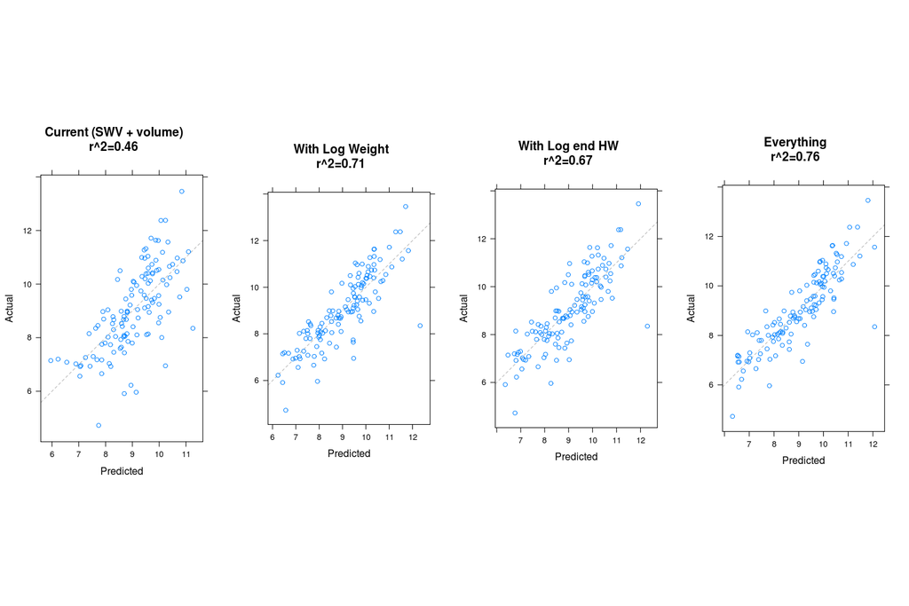

```
##
## Call:
## lm(formula = E.avg.dyn ~ SWV + m_volume, data = L, subset = !is.na(L$m_sed))
##
## Residuals:
##     Min      1Q  Median      3Q     Max
## -3.2835 -0.6269  0.0058  0.7533  2.6169
##
## Coefficients:
##               Estimate Std. Error t value Pr(>|t|)
## (Intercept) -6.7180744  1.5591870  -4.309 3.38e-05 ***
## SWV          0.0045552  0.0004462  10.209  < 2e-16 ***
## m_volume     1.9280541  0.5973221   3.228  0.00161 **
## ---
## Signif. codes:  0 '***' 0.001 '**' 0.01 '*' 0.05 '.' 0.1 ' ' 1
##
## Residual standard error: 1.152 on 120 degrees of freedom
## Multiple R-squared:  0.4649, Adjusted R-squared:  0.456
## F-statistic: 52.13 on 2 and 120 DF,  p-value: < 2.2e-16
##
##
## Call:
## lm(formula = E.avg.dyn ~ SWV + density + m_volume + hw.vfrac,
##     data = L, subset = !is.na(L$m_sed))
##
## Residuals:
##     Min      1Q  Median      3Q     Max
## -3.9763 -0.4081  0.0458  0.4933  1.7542
##
## Coefficients:
##               Estimate Std. Error t value Pr(>|t|)
## (Intercept) -1.527e+01  2.327e+00  -6.564 1.47e-09 ***
## SWV          5.385e-03  3.462e-04  15.554  < 2e-16 ***
## density      7.351e-03  1.961e-03   3.749 0.000277 ***
## m_volume     1.323e+00  4.485e-01   2.950 0.003835 **
## hw.vfrac    -3.361e+00  1.295e+00  -2.596 0.010636 *
## ---
## Signif. codes:  0 '***' 0.001 '**' 0.01 '*' 0.05 '.' 0.1 ' ' 1
##
## Residual standard error: 0.8568 on 118 degrees of freedom
```

[output cut: 36 more lines]

```
## (Intercept)  -1.481e+01  2.507e+00  -5.909 3.64e-08 ***
## SWV           5.044e-03  3.339e-04  15.108  < 2e-16 ***
## density       8.795e-03  2.283e-03   3.853 0.000194 ***
## m_volume      8.452e+00  4.310e+00   1.961 0.052331 .
## m_whorliness -9.294e-01  2.709e-01  -3.430 0.000840 ***
## hw.vfrac     -3.476e+00  1.260e+00  -2.758 0.006782 **
## m_waist       1.269e+01  4.630e+00   2.741 0.007107 **
## m_a2         -1.329e-01  5.087e-02  -2.613 0.010186 *
## weight       -6.934e-03  4.161e-03  -1.666 0.098377 .
## ---
## Signif. codes:  0 '***' 0.001 '**' 0.01 '*' 0.05 '.' 0.1 ' ' 1
##
## Residual standard error: 0.7937 on 114 degrees of freedom
## Multiple R-squared:  0.7588, Adjusted R-squared:  0.7419
## F-statistic: 44.84 on 8 and 114 DF,  p-value: < 2.2e-16
```

```r
myplot=function (m, lbl) {
  print(s<-summary(m))
  xyplot(m$model$E.avg.dyn ~ predict(m),
         panel=function(x,y,...) {
           panel.abline(c(0,1), col='grey70', lty=2)
           panel.xyplot(x,y,...)},
          aspect='iso',
         xlab='Predicted', ylab='Actual',
         main=sprintf('%s\nr^2=%0.2f',lbl,s$r.squared))
         #main=lbl, sub=expression(r^2==s$r.squared))
}
grid.arrange(myplot(m.best.current, lbl="Current (SWV + volume)"),
             myplot(m.best.withWeight, lbl="With Log Weight"),
             myplot(m.best.withHW, lbl="With Log end HW"),
             myplot(m.best, lbl="Everything"),
             nrow=1,
             as.table=TRUE)
```

*Does eliminating logs with significant compression wood visible on ends lead to better models?*

what % of lumber that is not from the cant has stiffness below 6GPa?

## 3.2 Warp

### 3.2.1 Best Linear Models

Use stepwise regression to select ‘best’ (in terms of AIC) linear model.

```r
best.linear.model = function (y,LL=NULL,plot=TRUE,...) {
  if (is.null(LL)) {

    LL=L[,predictors]
  }
  LL$y = y
  LL = na.omit(LL)#[complete.cases(LL),]
  scope = formula(paste("y~",paste(predictors,collapse='+')))
  #print(scope)
  m.init <- lm(y ~ SWV, LL, ...)
  #browser()
  m <- step(m.init, direction="both", scope=scope, trace=0)
  if (plot) {
    print(xyplot(LL$y ~ predict(m),aspect='iso',
                 panel=function(...){
                    panel.abline(c(0,1),col='grey70')
                    panel.xyplot(...)},
                 main=deparse(substitute(y)),
                 xlab='predicted', ylab='observed'))
  }
  return(m)
}
```

#### 3.2.1.1 Bow

```r
summary(m.best.bow_avg <- best.linear.model(L$bow_avg))
```

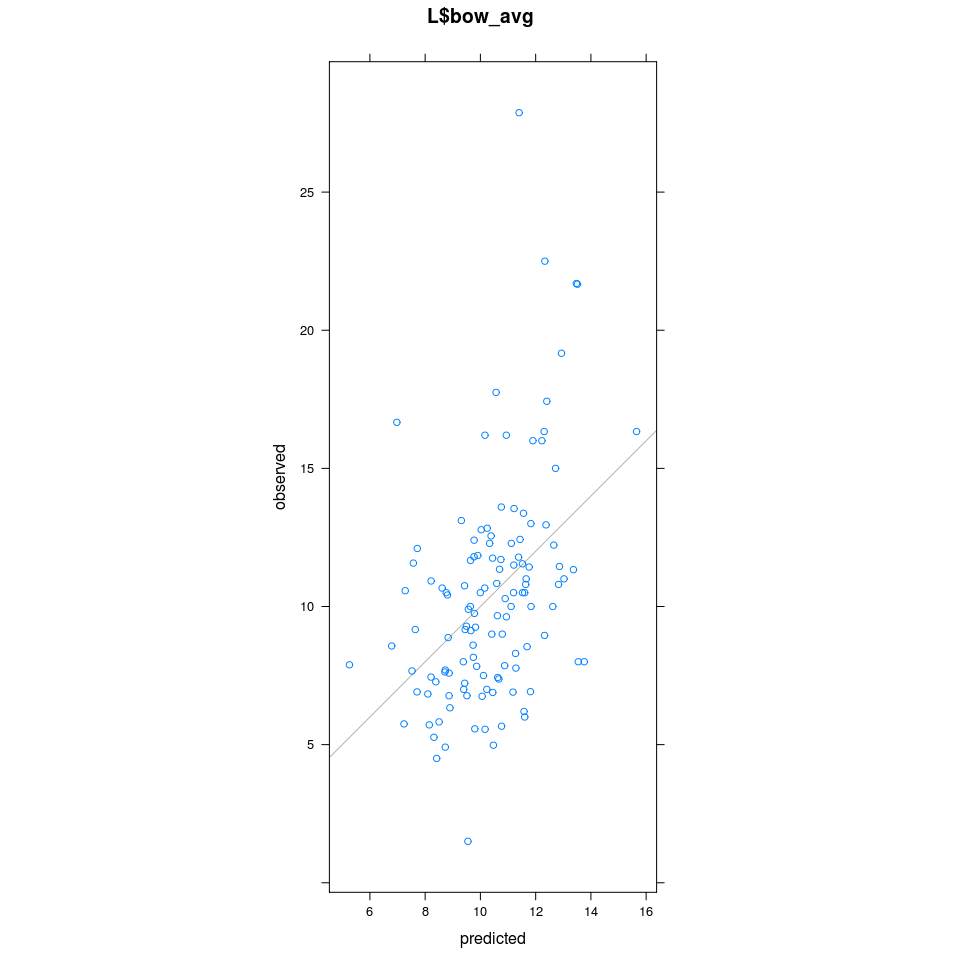

```
##
## Call:
## lm(formula = y ~ SWV + density + m_taper, data = LL)
##
## Residuals:
##     Min      1Q  Median      3Q     Max
## -8.0477 -2.3025 -0.5719  1.8777 16.4729
##
## Coefficients:
##              Estimate Std. Error t value Pr(>|t|)
## (Intercept) 50.130387   7.768906   6.453 2.48e-09 ***
## SWV         -0.006338   0.001486  -4.265 4.04e-05 ***
## density     -0.016751   0.005007  -3.345  0.00110 **
## m_taper     -0.344437   0.128428  -2.682  0.00836 **
## ---
## Signif. codes:  0 '***' 0.001 '**' 0.01 '*' 0.05 '.' 0.1 ' ' 1
##
## Residual standard error: 3.637 on 119 degrees of freedom
## Multiple R-squared:  0.1857, Adjusted R-squared:  0.1651
## F-statistic: 9.044 on 3 and 119 DF,  p-value: 1.925e-05
```

```r
summary(m.best.bow_p50 <- best.linear.model(L$bow_p50))
```

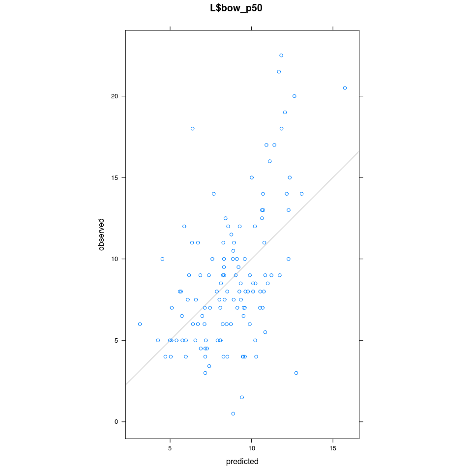

```
##
## Call:
## lm(formula = y ~ SWV + density + m_led + m_a0 + m_whorliness +
##     weight, data = LL)
##
## Residuals:
##     Min      1Q  Median      3Q     Max
## -9.7477 -2.4296 -0.4523  2.1092 11.6209
##
## Coefficients:
##               Estimate Std. Error t value Pr(>|t|)
## (Intercept)  48.036399  11.206653   4.286 3.77e-05 ***
## SWV          -0.007397   0.001610  -4.594 1.11e-05 ***
## density      -0.014851   0.006826  -2.176   0.0316 *
## m_led        -0.054103   0.029463  -1.836   0.0689 .
## m_a0          0.089035   0.035585   2.502   0.0137 *
## m_whorliness -2.859383   1.304531  -2.192   0.0304 *
## weight       -0.017303   0.012097  -1.430   0.1553
## ---
## Signif. codes:  0 '***' 0.001 '**' 0.01 '*' 0.05 '.' 0.1 ' ' 1
##
## Residual standard error: 3.762 on 116 degrees of freedom
## Multiple R-squared:  0.2656, Adjusted R-squared:  0.2276
## F-statistic: 6.991 on 6 and 116 DF,  p-value: 2.304e-06
```

```r
summary(m.best.bow_p75 <- best.linear.model(L$bow_p75))
```

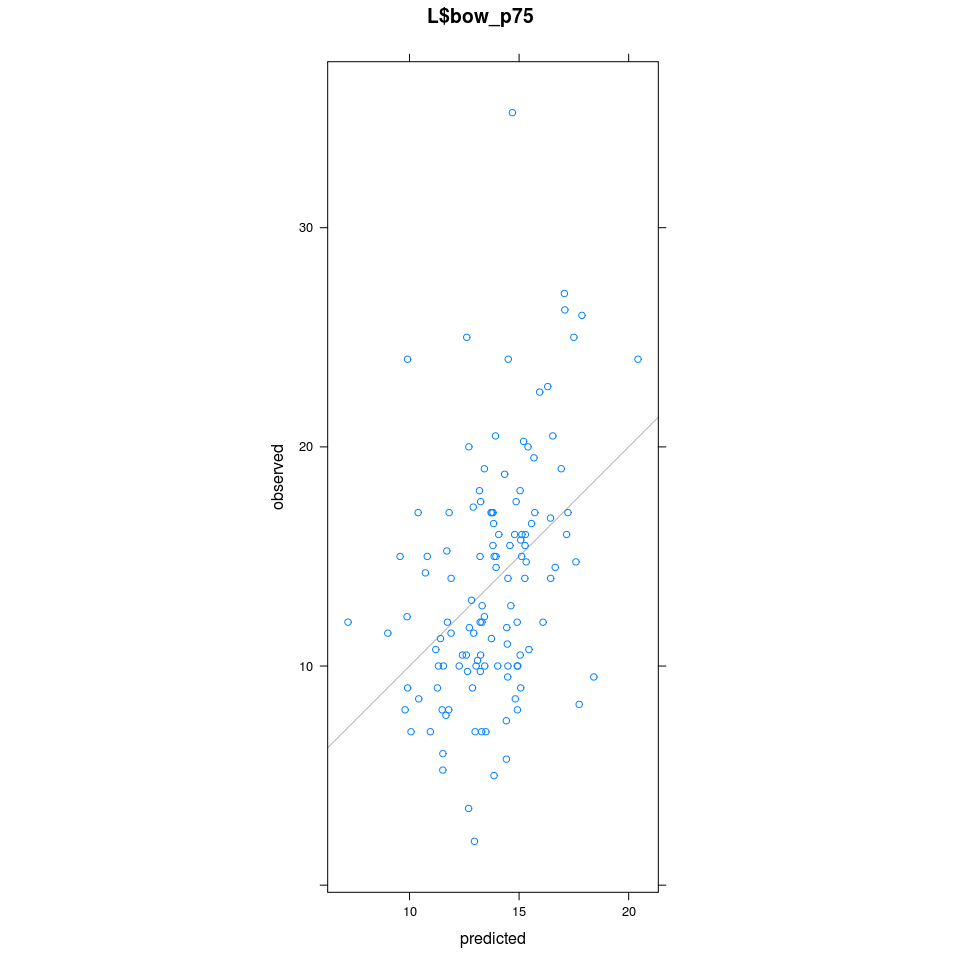

```
##
## Call:
## lm(formula = y ~ SWV + m_taper + density, data = LL)
##
## Residuals:
##      Min       1Q   Median       3Q      Max
## -10.9639  -3.2509  -0.4905   3.2151  20.5563
##
## Coefficients:
##              Estimate Std. Error t value Pr(>|t|)
## (Intercept) 62.605957  10.910506   5.738 7.43e-08 ***
## SWV         -0.007785   0.002087  -3.730 0.000295 ***
## m_taper     -0.532468   0.180362  -2.952 0.003802 **
## density     -0.019486   0.007032  -2.771 0.006483 **
## ---
## Signif. codes:  0 '***' 0.001 '**' 0.01 '*' 0.05 '.' 0.1 ' ' 1
##
## Residual standard error: 5.108 on 119 degrees of freedom
## Multiple R-squared:  0.1575, Adjusted R-squared:  0.1363
## F-statistic: 7.417 on 3 and 119 DF,  p-value: 0.0001348
```

SWV, weight, density, whorliness and taper best predictors. Median bow best predicted.

#### 3.2.1.2 Crook

```r
summary(m.best.crook_avg <- best.linear.model(L$crook_avg))
```

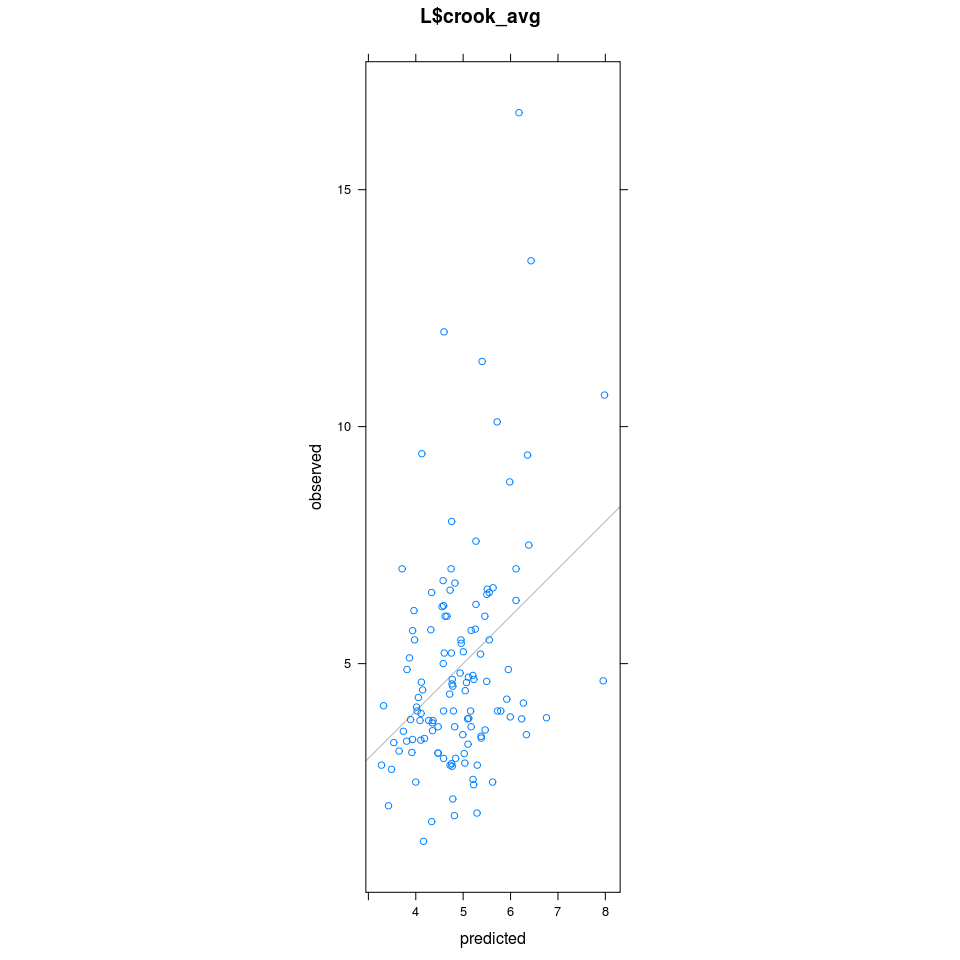

```
##
## Call:
## lm(formula = y ~ density + sweep.prod + m_a2, data = LL)
##
## Residuals:
##     Min      1Q  Median      3Q     Max
## -3.4455 -1.4960 -0.3582  0.9658 10.4465
##
## Coefficients:
##              Estimate Std. Error t value Pr(>|t|)
## (Intercept) 11.763314   2.899084   4.058  8.9e-05 ***
## density     -0.007900   0.003032  -2.605   0.0104 *
## sweep.prod   1.885969   0.839433   2.247   0.0265 *
## m_a2        -0.012981   0.006966  -1.863   0.0649 .
## ---
## Signif. codes:  0 '***' 0.001 '**' 0.01 '*' 0.05 '.' 0.1 ' ' 1
##
## Residual standard error: 2.238 on 119 degrees of freedom
## Multiple R-squared:  0.1293, Adjusted R-squared:  0.1073
## F-statistic: 5.888 on 3 and 119 DF,  p-value: 0.0008794
```

```r
summary(m.best.crook_p50 <- best.linear.model(L$crook_p50))
```

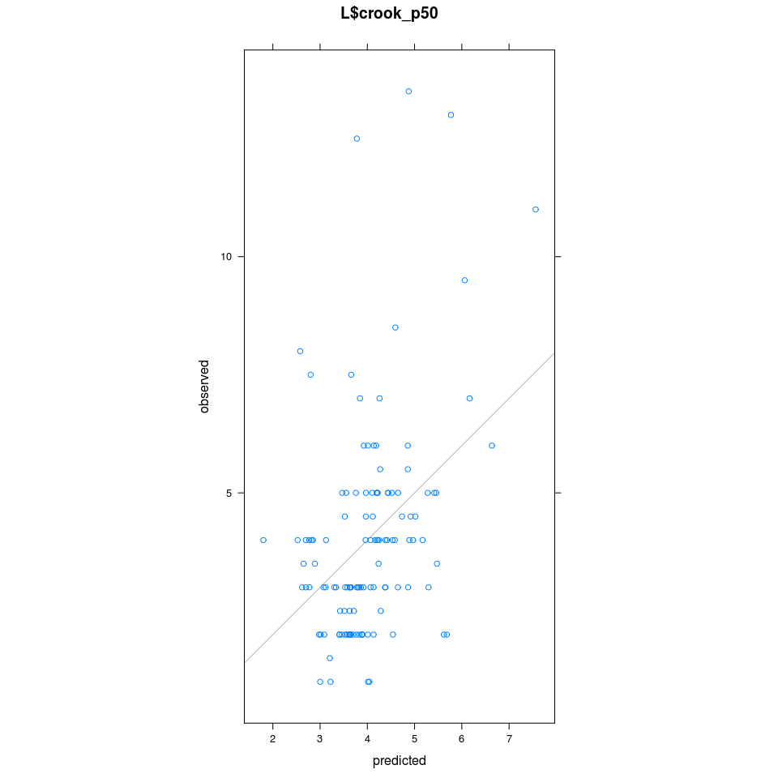

```
##
## Call:
## lm(formula = y ~ SWV + hw.vfrac + sweep.prod + m_taper, data = LL)
##
## Residuals:
##     Min      1Q  Median      3Q     Max
## -3.6810 -1.3799 -0.4174  0.8419  8.7215
##
## Coefficients:
##               Estimate Std. Error t value Pr(>|t|)
## (Intercept)  9.8372683  3.2768419   3.002  0.00327 **
## SWV         -0.0020108  0.0009157  -2.196  0.03005 *
## hw.vfrac     6.2981503  1.9614745   3.211  0.00171 **
## sweep.prod   1.6186090  0.8178916   1.979  0.05014 .
## m_taper     -0.1322546  0.0747625  -1.769  0.07948 .
## ---
## Signif. codes:  0 '***' 0.001 '**' 0.01 '*' 0.05 '.' 0.1 ' ' 1
##
## Residual standard error: 2.119 on 118 degrees of freedom
## Multiple R-squared:  0.1552, Adjusted R-squared:  0.1265
## F-statistic: 5.418 on 4 and 118 DF,  p-value: 0.0004857
```

```r
summary(m.best.crook_p75 <- best.linear.model(L$crook_p75))
```

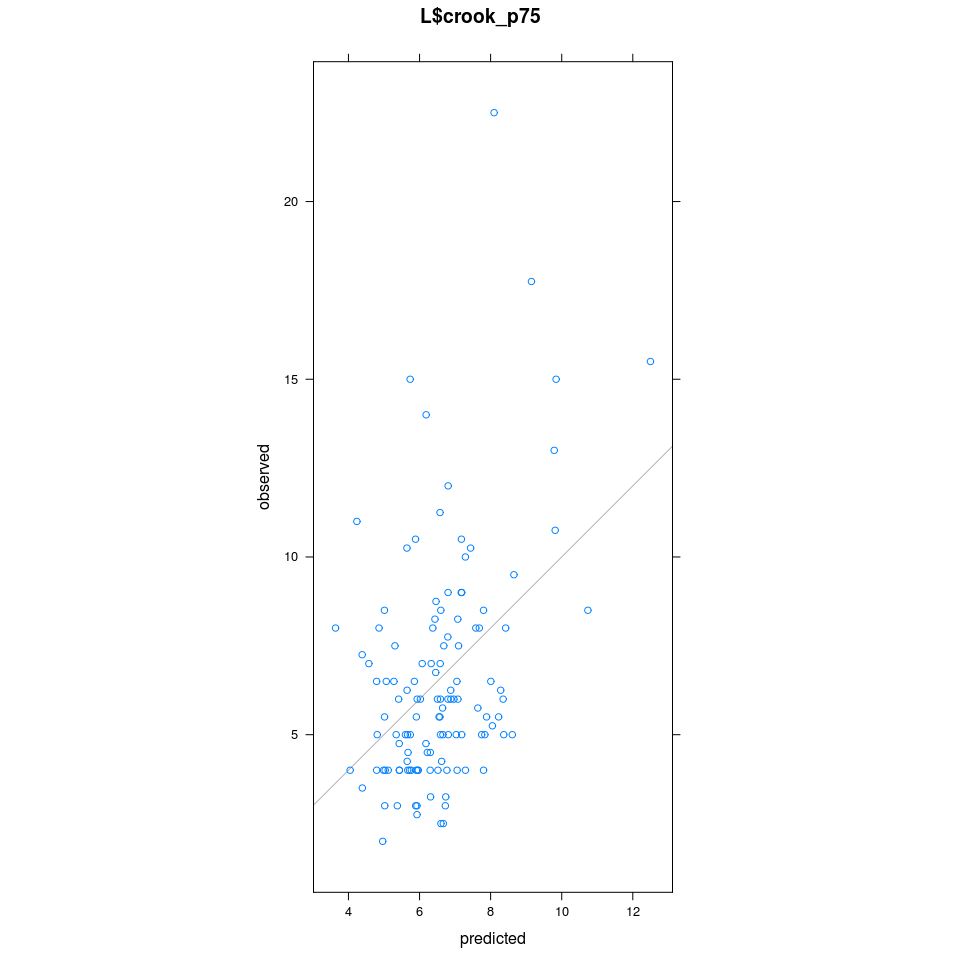

```
##
## Call:
## lm(formula = y ~ SWV + density + sweep.prod + m_taper, data = LL)
##
## Residuals:
##     Min      1Q  Median      3Q     Max
## -4.1687 -1.9566 -0.6777  1.1977 14.4027
##
## Coefficients:
##              Estimate Std. Error t value Pr(>|t|)
## (Intercept) 28.177452   6.780630   4.156 6.17e-05 ***
## SWV         -0.002311   0.001259  -1.835  0.06901 .
## density     -0.014306   0.004252  -3.365  0.00103 **
## sweep.prod   2.691696   1.167080   2.306  0.02284 *
## m_taper     -0.165324   0.106147  -1.557  0.12203
## ---
## Signif. codes:  0 '***' 0.001 '**' 0.01 '*' 0.05 '.' 0.1 ' ' 1
##
## Residual standard error: 3.001 on 118 degrees of freedom
## Multiple R-squared:  0.1772, Adjusted R-squared:  0.1493
## F-statistic: 6.355 on 4 and 118 DF,  p-value: 0.0001149
```

#### 3.2.1.3 Combination Warp

Stan combined bow and crook using WPA grade limits.

```r
combined_warp = L$crook_avg/75 + L$bow_avg/25
summary(m.best.combined_warp <- best.linear.model(combined_warp))
```

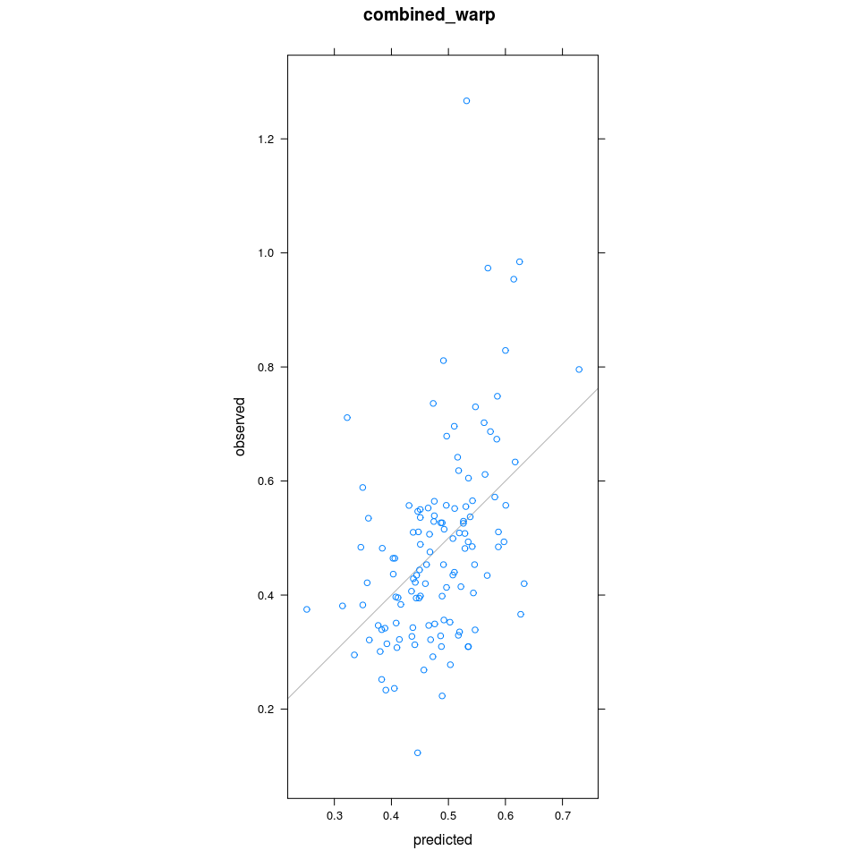

```
##
## Call:
## lm(formula = y ~ SWV + density + m_taper, data = LL)
##
## Residuals:
##      Min       1Q   Median       3Q      Max
## -0.32265 -0.09364 -0.01027  0.06659  0.73476
##
## Coefficients:
##               Estimate Std. Error t value Pr(>|t|)
## (Intercept)  2.3008456  0.3288043   6.998 1.65e-10 ***
## SWV         -0.0002806  0.0000629  -4.461 1.87e-05 ***
## density     -0.0008098  0.0002119  -3.822 0.000212 ***
## m_taper     -0.0149063  0.0054355  -2.742 0.007042 **
## ---
## Signif. codes:  0 '***' 0.001 '**' 0.01 '*' 0.05 '.' 0.1 ' ' 1
##
## Residual standard error: 0.1539 on 119 degrees of freedom
## Multiple R-squared:  0.2091, Adjusted R-squared:  0.1892
## F-statistic: 10.49 on 3 and 119 DF,  p-value: 3.575e-06
```

What happens if we toss a couple of outliers?

```r
L$SWILogNumber[combined_warp>1.2] # 222
```

```
## [1] 222
```

```r
L$SWILogNumber[combined_warp<0.2] # 103
```

```
## [1] 103
```

```r
subset = !L$SWILogNumber%in%c(103,222)
summary(m.best.combined_warp <- best.linear.model(combined_warp[subset], LL=L[subset,predictors]))
```

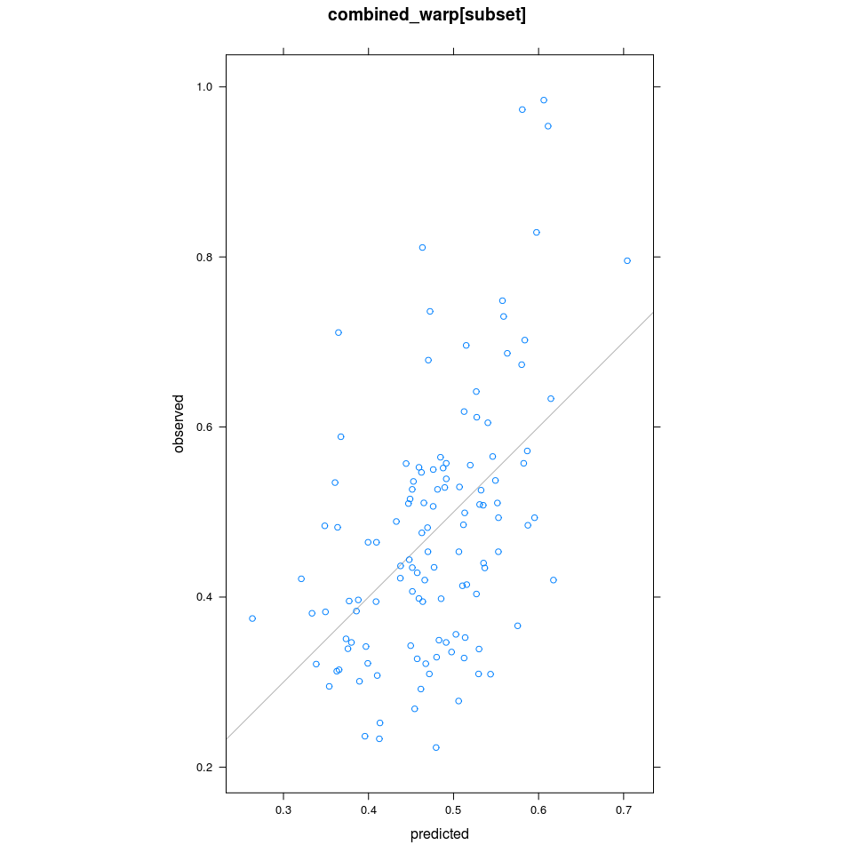

```
##
## Call:
## lm(formula = y ~ SWV + density + m_taper + weight, data = LL)
##
## Residuals:
##      Min       1Q   Median       3Q      Max
## -0.25644 -0.09717 -0.01417  0.07387  0.39249
##
## Coefficients:
##               Estimate Std. Error t value Pr(>|t|)
## (Intercept)  2.151e+00  2.904e-01   7.409 2.23e-11 ***
## SWV         -2.719e-04  5.655e-05  -4.808 4.61e-06 ***
## density     -6.330e-04  1.934e-04  -3.274  0.00140 **
## m_taper     -1.561e-02  4.916e-03  -3.176  0.00191 **
## weight      -9.961e-05  7.043e-05  -1.414  0.15991
## ---
## Signif. codes:  0 '***' 0.001 '**' 0.01 '*' 0.05 '.' 0.1 ' ' 1
##
## Residual standard error: 0.1353 on 116 degrees of freedom
## Multiple R-squared:  0.2465, Adjusted R-squared:  0.2205
## F-statistic: 9.486 on 4 and 116 DF,  p-value: 1.138e-06
```

A little better, but nothing spectacular.

Can a random forest model do better?

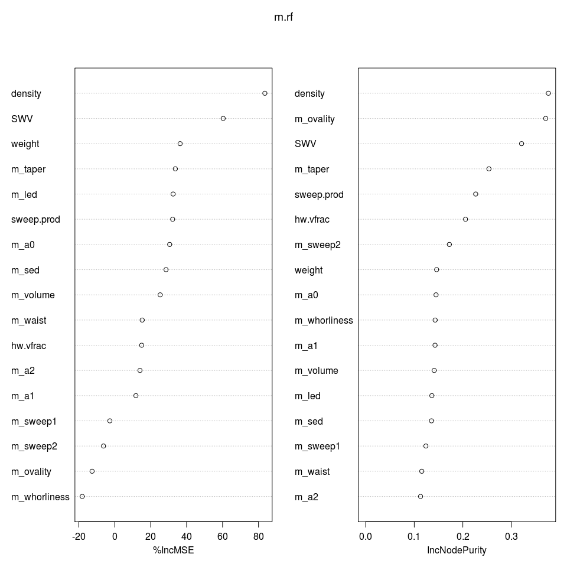

```r
LL=L[,predictors]
LL$combined_warp = combined_warp
LL = na.omit(LL)
m.rf <- randomForest(combined_warp ~ ., LL, importance=TRUE, ntree=50000)
par(mfcol=c(1,1))
varImpPlot(m.rf)
```

```r
print(m.rf)
```

```
##
## Call:
##  randomForest(formula = combined_warp ~ ., data = LL, importance = TRUE,      ntree = 50000)
##                Type of random forest: regression
##                      Number of trees: 50000
## No. of variables tried at each split: 5
##
##           Mean of squared residuals: 0.02999843
##                     % Var explained: -3.48
```

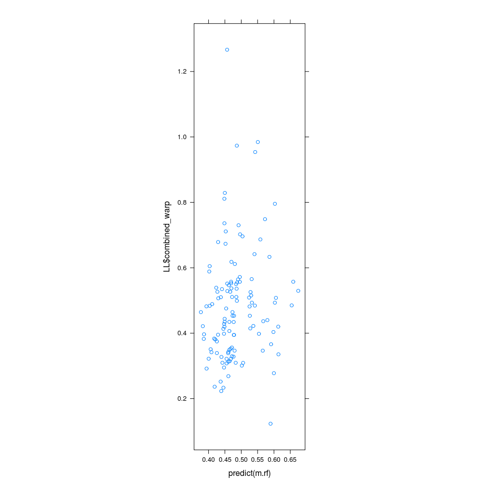

```r
xyplot(LL$combined_warp ~ predict(m.rf), aspect='iso')
```

Lousy results, but interesting that log green density turns up as the most favoured predictor, followed by SWV, taper and ovality.

What about other variable selection approaches?

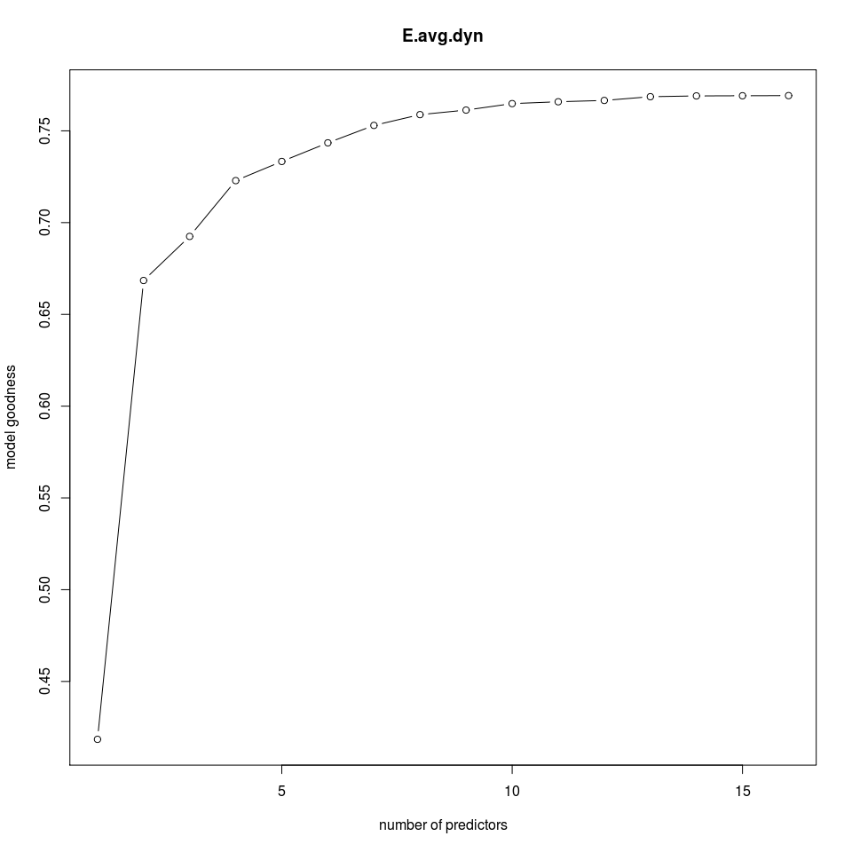

```
##
##  E.avg.dyn
## 1: SWV
## 2: SWV, density
## 3: SWV, m_volume, density
## 4: SWV, m_led, m_whorliness, density
## 5: SWV, m_led, m_whorliness, density, hw.vfrac
## 6: SWV, m_led, m_waist, m_whorliness, density, hw.vfrac
## 7: SWV, m_volume, m_a2, m_waist, m_whorliness, density, hw.vfrac
## 8: SWV, m_volume, m_a2, m_waist, m_whorliness, weight, density, hw.vfrac
## 9: SWV, m_volume, m_a2, m_waist, m_whorliness, m_sweep2, weight, density, hw.vfrac
## 10: SWV, m_volume, m_a2, m_waist, m_whorliness, m_sweep1, weight, density, hw.vfrac, sweep.prod
## 11: SWV, m_volume, m_a0, m_a2, m_waist, m_whorliness, m_sweep1, weight, density, hw.vfrac, sweep.prod
## 12: SWV, m_volume, m_led, m_a0, m_a2, m_taper, m_waist, m_whorliness, m_sweep1, density, hw.vfrac, sweep.prod
## 13: SWV, m_volume, m_led, m_a0, m_a1, m_a2, m_waist, m_whorliness, m_sweep1, weight, density, hw.vfrac, sweep.prod
## 14: SWV, m_volume, m_led, m_sed, m_a0, m_a1, m_a2, m_waist, m_whorliness, m_sweep1, weight, density, hw.vfrac, sweep.prod
## 15: SWV, m_volume, m_led, m_sed, m_a0, m_a1, m_a2, m_waist, m_ovality, m_whorliness, m_sweep1, weight, density, hw.vfrac, sweep.prod
## 16: SWV, m_volume, m_led, m_sed, m_a0, m_a1, m_a2, m_taper, m_waist, m_ovality, m_whorliness, m_sweep1, weight, density, hw.vfrac, sweep.prod
```

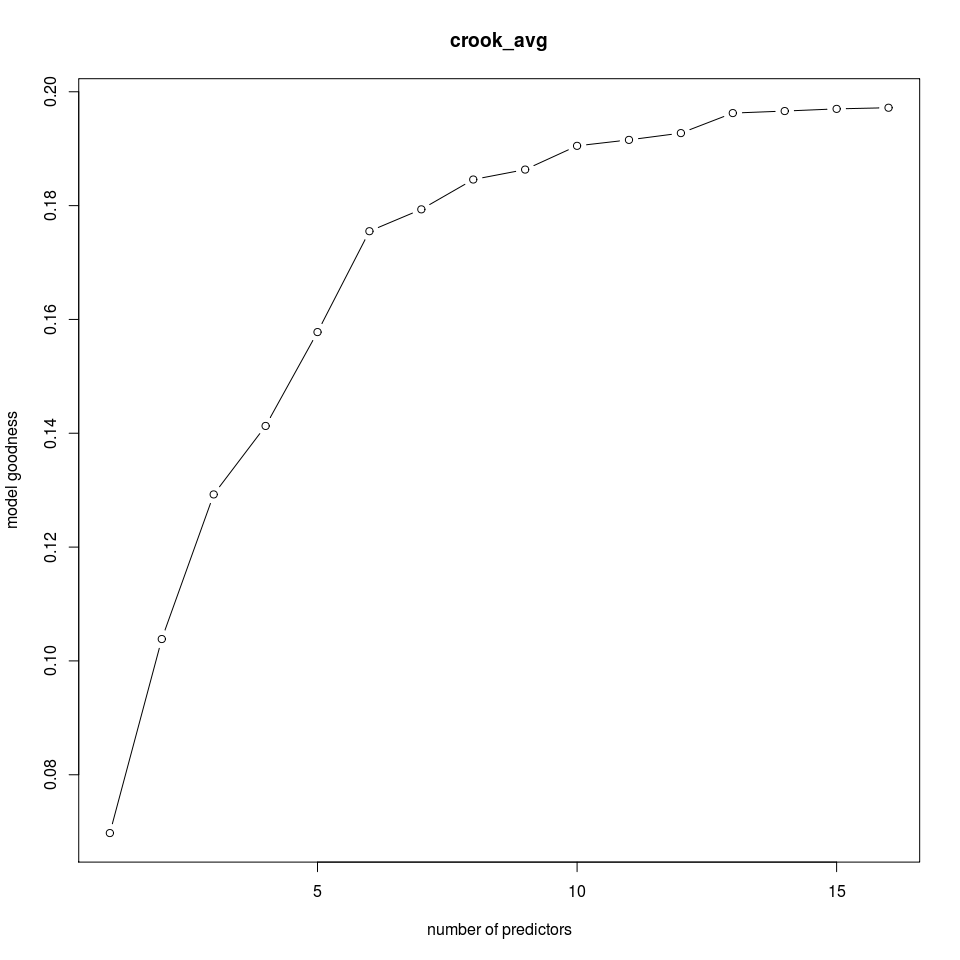

```
##
##  crook_avg
## 1: density
## 2: density, sweep.prod
## 3: m_a2, density, sweep.prod
## 4: SWV, m_a2, density, sweep.prod
## 5: m_a1, m_taper, m_waist, density, sweep.prod
## 6: SWV, m_a1, m_taper, m_waist, density, sweep.prod
## 7: SWV, m_a1, m_taper, m_waist, density, hw.vfrac, sweep.prod
## 8: SWV, m_a1, m_taper, m_waist, m_whorliness, density, hw.vfrac, sweep.prod
## 9: SWV, m_a1, m_a2, m_taper, m_waist, m_whorliness, density, hw.vfrac, sweep.prod
## 10: SWV, m_sed, m_a0, m_a1, m_taper, m_waist, m_whorliness, density, hw.vfrac, sweep.prod
## 11: SWV, m_volume, m_a1, m_a2, m_taper, m_waist, m_whorliness, weight, density, hw.vfrac, sweep.prod
## 12: SWV, m_volume, m_led, m_a1, m_a2, m_taper, m_waist, m_whorliness, weight, density, hw.vfrac, sweep.prod
## 13: SWV, m_volume, m_led, m_sed, m_a1, m_a2, m_taper, m_waist, m_whorliness, weight, density, hw.vfrac, sweep.prod
## 14: SWV, m_volume, m_led, m_sed, m_a1, m_a2, m_taper, m_waist, m_whorliness, m_sweep2, weight, density, hw.vfrac, sweep.prod
## 15: SWV, m_volume, m_led, m_sed, m_a1, m_a2, m_taper, m_waist, m_whorliness, m_sweep1, m_sweep2, weight, density, hw.vfrac, sweep.prod
## 16: SWV, m_volume, m_led, m_sed, m_a0, m_a1, m_a2, m_taper, m_waist, m_whorliness, m_sweep1, m_sweep2, weight, density, hw.vfrac, sweep.prod
```

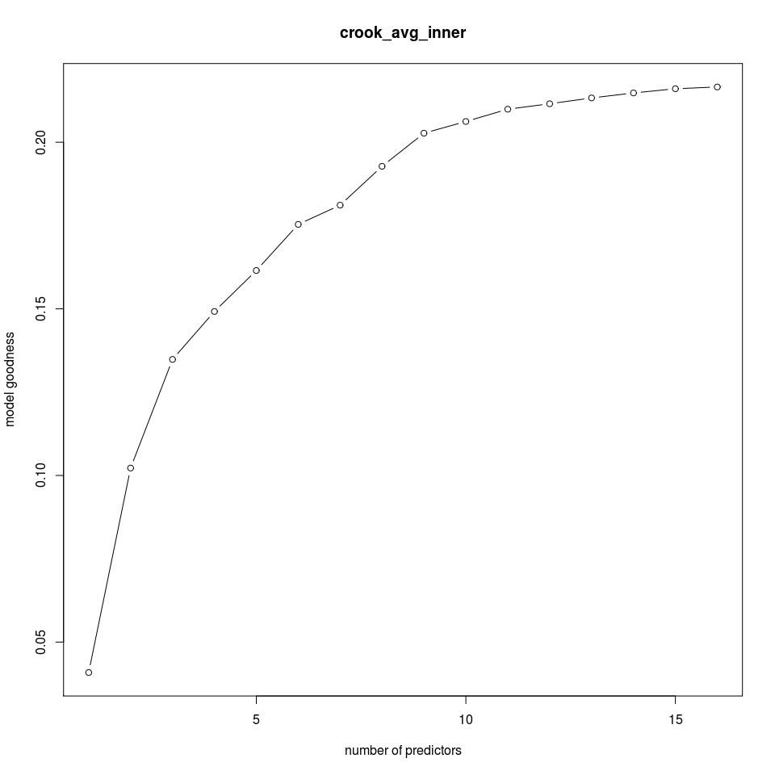

```
##
##  crook_avg_inner
## 1: sweep.prod
## 2: m_volume, weight
## 3: SWV, m_volume, weight
## 4: m_volume, m_a1, weight, sweep.prod
## 5: SWV, m_volume, m_a2, weight, sweep.prod
## 6: SWV, m_volume, m_a2, m_waist, weight, sweep.prod
## 7: SWV, m_volume, m_a1, m_taper, m_waist, weight, sweep.prod
## 8: SWV, m_led, m_a0, m_a1, m_taper, m_waist, density, sweep.prod
## 9: SWV, m_led, m_a0, m_a1, m_a2, m_taper, m_waist, density, sweep.prod
## 10: SWV, m_led, m_sed, m_a0, m_a1, m_a2, m_taper, m_waist, density, sweep.prod
## 11: SWV, m_led, m_sed, m_a0, m_a1, m_a2, m_taper, m_waist, m_whorliness, density, sweep.prod
## 12: SWV, m_led, m_sed, m_a0, m_a1, m_a2, m_taper, m_waist, m_ovality, m_whorliness, density, sweep.prod
## 13: SWV, m_led, m_sed, m_a0, m_a1, m_a2, m_taper, m_waist, m_ovality, m_sweep1, m_sweep2, density, sweep.prod
## 14: SWV, m_led, m_sed, m_a0, m_a1, m_a2, m_taper, m_waist, m_ovality, m_whorliness, m_sweep1, m_sweep2, density, sweep.prod
## 15: SWV, m_led, m_sed, m_a0, m_a1, m_a2, m_taper, m_waist, m_ovality, m_whorliness, m_sweep1, m_sweep2, weight, density, sweep.prod
## 16: SWV, m_led, m_sed, m_a0, m_a1, m_a2, m_taper, m_waist, m_ovality, m_whorliness, m_sweep1, m_sweep2, weight, density, hw.vfrac, sweep.prod
```

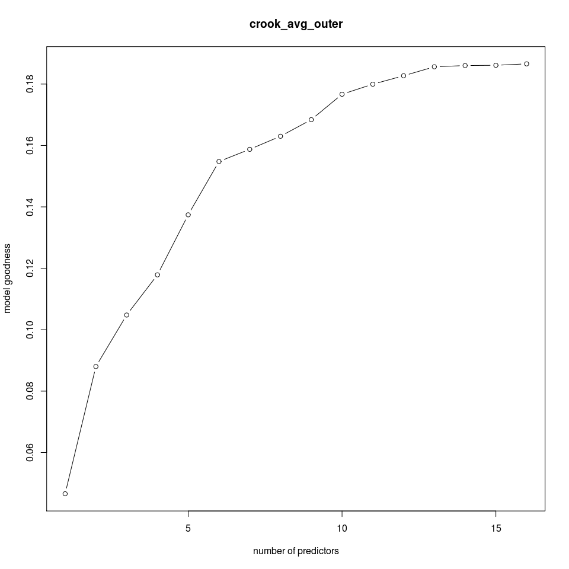

```
##
##  crook_avg_outer
## 1: m_waist
## 2: SWV, m_led
## 3: SWV, m_led, m_waist
## 4: SWV, m_sed, m_waist, m_whorliness
## 5: SWV, m_sed, m_a0, m_a2, m_whorliness
## 6: SWV, m_sed, m_a0, m_a2, m_whorliness, m_sweep1
## 7: SWV, m_sed, m_a0, m_a2, m_whorliness, m_sweep1, density
## 8: SWV, m_sed, m_a0, m_a1, m_taper, m_waist, m_whorliness, m_sweep1
## 9: SWV, m_volume, m_sed, m_a0, m_a2, m_whorliness, m_sweep1, weight, density
## 10: SWV, m_volume, m_sed, m_a0, m_a2, m_waist, m_whorliness, m_sweep1, weight, density
## 11: SWV, m_volume, m_led, m_sed, m_a0, m_a2, m_waist, m_whorliness, m_sweep1, weight, density
## 12: SWV, m_volume, m_led, m_sed, m_a0, m_a2, m_taper, m_waist, m_whorliness, m_sweep1, weight, density
## 13: SWV, m_volume, m_led, m_sed, m_a0, m_a1, m_a2, m_taper, m_waist, m_whorliness, m_sweep1, weight, density
## 14: SWV, m_volume, m_led, m_sed, m_a0, m_a1, m_a2, m_taper, m_waist, m_ovality, m_whorliness, m_sweep1, weight, density
## 15: SWV, m_volume, m_led, m_sed, m_a0, m_a1, m_a2, m_taper, m_waist, m_ovality, m_whorliness, m_sweep1, weight, density, sweep.prod
## 16: SWV, m_volume, m_led, m_sed, m_a0, m_a1, m_a2, m_taper, m_waist, m_ovality, m_whorliness, m_sweep1, m_sweep2, weight, density, sweep.prod
```

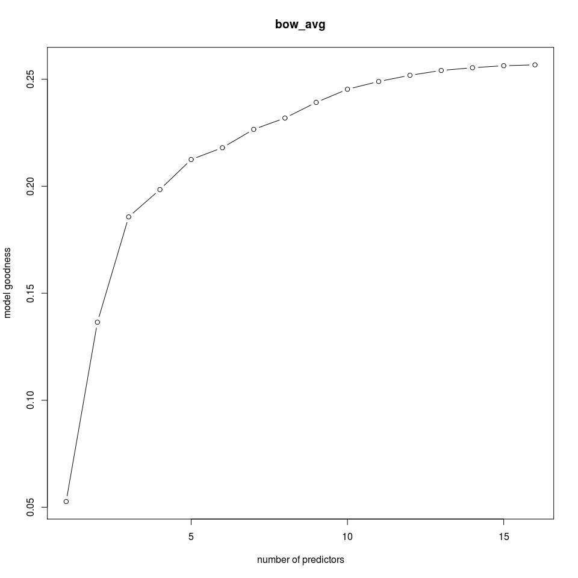

```
##
##  bow_avg
## 1: SWV
## 2: SWV, density
## 3: SWV, m_taper, density
## 4: SWV, m_led, m_a0, density
## 5: SWV, m_led, m_a0, m_ovality, density
## 6: SWV, m_led, m_a0, m_ovality, weight, density
## 7: SWV, m_led, m_a0, m_ovality, m_whorliness, weight, density
## 8: SWV, m_volume, m_a0, m_a1, m_a2, m_taper, m_whorliness, density
## 9: SWV, m_volume, m_a0, m_a1, m_a2, m_taper, m_ovality, m_whorliness, density
## 10: SWV, m_volume, m_led, m_a0, m_a1, m_a2, m_taper, m_ovality, m_whorliness, density
## 11: SWV, m_volume, m_led, m_a0, m_a1, m_a2, m_taper, m_ovality, m_whorliness, m_sweep1, density
## 12: SWV, m_volume, m_led, m_sed, m_a0, m_a1, m_a2, m_taper, m_ovality, m_whorliness, m_sweep1, density
## 13: SWV, m_volume, m_led, m_sed, m_a0, m_a1, m_a2, m_taper, m_ovality, m_whorliness, m_sweep1, weight, density
## 14: SWV, m_volume, m_led, m_sed, m_a0, m_a1, m_a2, m_taper, m_ovality, m_whorliness, m_sweep1, weight, density, sweep.prod
## 15: SWV, m_volume, m_led, m_sed, m_a0, m_a1, m_a2, m_taper, m_ovality, m_whorliness, m_sweep1, weight, density, hw.vfrac, sweep.prod
## 16: SWV, m_volume, m_led, m_sed, m_a0, m_a1, m_a2, m_taper, m_ovality, m_whorliness, m_sweep1, m_sweep2, weight, density, hw.vfrac, sweep.prod
```

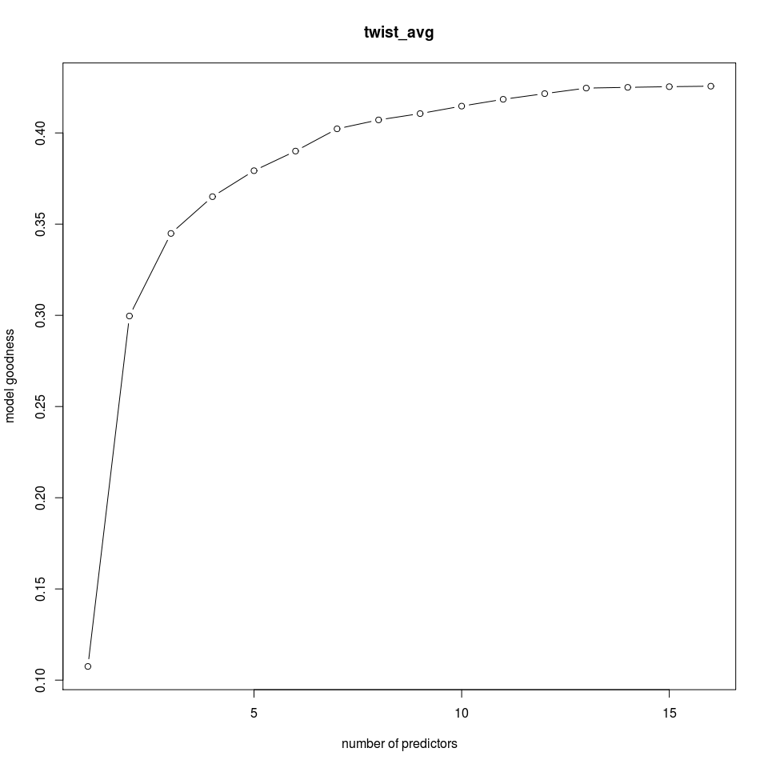

```
##
##  twist_avg
## 1: SWV
## 2: SWV, m_led
## 3: SWV, m_volume, weight
## 4: SWV, m_volume, m_waist, weight
## 5: SWV, m_volume, m_waist, m_sweep1, weight
## 6: SWV, m_volume, m_a2, m_waist, m_sweep1, weight
## 7: SWV, m_volume, m_a1, m_taper, m_waist, m_sweep1, weight
## 8: SWV, m_volume, m_a1, m_taper, m_waist, m_ovality, m_sweep1, weight
## 9: SWV, m_volume, m_a1, m_a2, m_taper, m_waist, m_ovality, m_sweep1, density
## 10: SWV, m_volume, m_a1, m_a2, m_taper, m_waist, m_ovality, m_sweep1, m_sweep2, density
## 11: SWV, m_volume, m_led, m_a0, m_a1, m_taper, m_waist, m_ovality, m_sweep1, m_sweep2, density
## 12: SWV, m_led, m_a0, m_a1, m_a2, m_taper, m_waist, m_ovality, m_sweep1, m_sweep2, density, hw.vfrac
## 13: SWV, m_volume, m_led, m_a0, m_a1, m_a2, m_taper, m_waist, m_ovality, m_sweep1, m_sweep2, density, hw.vfrac
## 14: SWV, m_volume, m_led, m_a0, m_a1, m_a2, m_taper, m_waist, m_ovality, m_whorliness, m_sweep1, m_sweep2, density, hw.vfrac
## 15: SWV, m_volume, m_led, m_sed, m_a0, m_a1, m_a2, m_taper, m_waist, m_ovality, m_whorliness, m_sweep1, m_sweep2, density, hw.vfrac
## 16: SWV, m_volume, m_led, m_sed, m_a0, m_a1, m_a2, m_taper, m_waist, m_ovality, m_whorliness, m_sweep1, m_sweep2, density, hw.vfrac, sweep.prod
```

```r
LL <- L[,predictors]
for (lmeas in c('E.avg.dyn','crook_avg','crook_avg_inner','crook_avg_outer','bow_avg','twist_avg')) {
  LL$y = L[,lmeas]
  m.0 <- lm(y ~ ., LL)
  Hmat <- lmHmat(m.0)
  Eleaps <- eleaps(Hmat$mat, kmin=1, kmax=length(predictors)-1, H=Hmat$H, r=Hmat$r)
  plot(Eleaps$bestvalues, type='b', main=lmeas, ylab="model goodness", xlab="number of predictors")
  cat(paste("\n",lmeas,"\n"))
  for (i in 1:nrow(Eleaps$bestsets)) {
    cat(paste(i,': ',paste(colnames(Hmat$mat)[Eleaps$bestsets[i,1:i]],collapse=", "),"\n", sep=""))
    # AIC?
  }
}
```

Note: other R packages include bestglm, subselect, leaps, glmulti.

```r
LL <- L[,predictors]
LL$y = L$E.avg.dyn
m.0 <- glm(y ~ ., LL, family=gaussian(link="identity")) # equiv to a linear model
m.best <- glmulti(m.0, method="l", level=1) # level=1 forces no interactions
```

```
## Initialization...
## TASK: Exhaustive screening of candidate set, branch-and-bound algorithm.
## [ Be sure to have package leaps installed ]
## Fitting...
## Completed.
## 200 first best models identified.
```

```r
# sloooooooow!
```

## 3.3 Inner and Outer Models

### 3.3.1 MoE

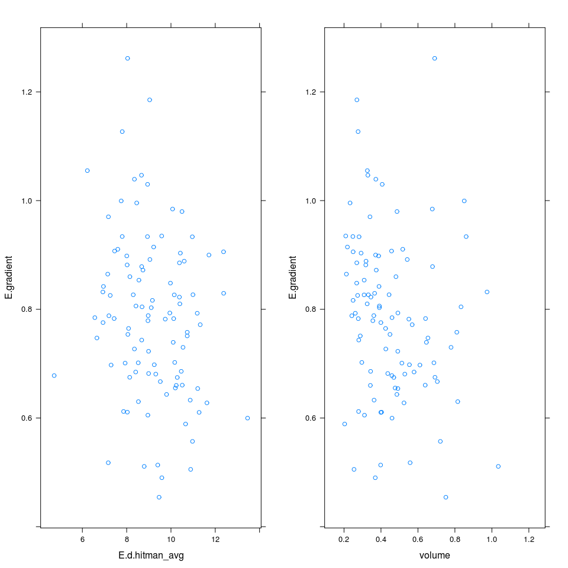

```r
grid.arrange(
  xyplot(E.gradient ~ E.d.hitman_avg, L),
  xyplot(E.gradient ~ volume, L),
ncol=2)
```

Reasonable range in inner:outer stiffness. Independent of overall stiffness and size.

See models below.

### 3.3.2 Crook

```r
  summary(m <- best.linear.model(L$crook_avg))
```

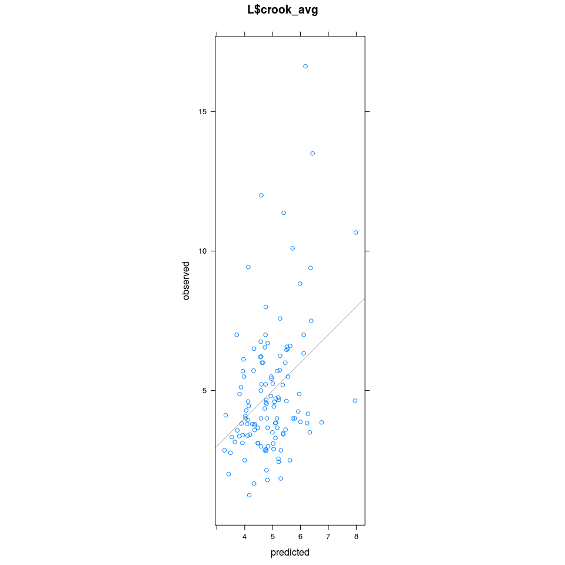

```
##
## Call:
## lm(formula = y ~ density + sweep.prod + m_a2, data = LL)
##
## Residuals:
##     Min      1Q  Median      3Q     Max
## -3.4455 -1.4960 -0.3582  0.9658 10.4465
##
## Coefficients:
##              Estimate Std. Error t value Pr(>|t|)
## (Intercept) 11.763314   2.899084   4.058  8.9e-05 ***
## density     -0.007900   0.003032  -2.605   0.0104 *
## sweep.prod   1.885969   0.839433   2.247   0.0265 *
## m_a2        -0.012981   0.006966  -1.863   0.0649 .
## ---
## Signif. codes:  0 '***' 0.001 '**' 0.01 '*' 0.05 '.' 0.1 ' ' 1
##
## Residual standard error: 2.238 on 119 degrees of freedom
## Multiple R-squared:  0.1293, Adjusted R-squared:  0.1073
## F-statistic: 5.888 on 3 and 119 DF,  p-value: 0.0008794
```

```r
  summary(m <- best.linear.model(L$crook_avg_inner))
```

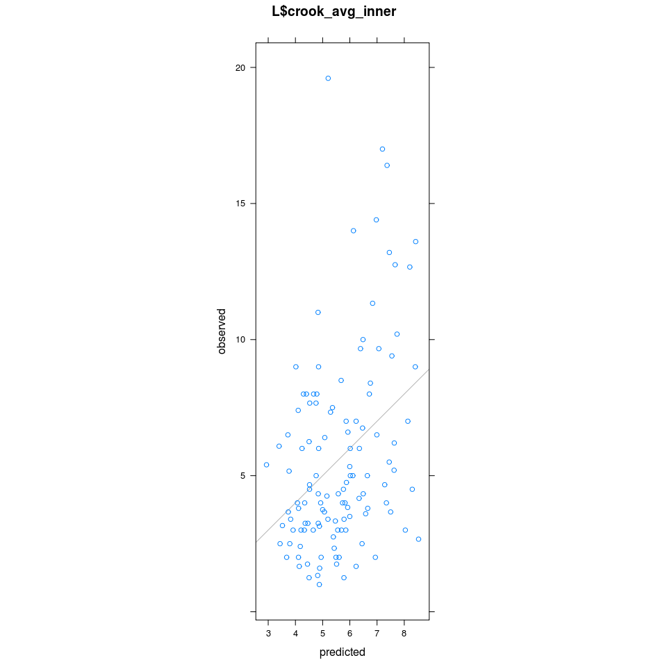

```
##
## Call:
## lm(formula = y ~ SWV + m_volume + weight, data = LL)
##
## Residuals:
##     Min      1Q  Median      3Q     Max
## -5.8585 -2.2262 -0.9317  1.9024 14.3969
##
## Coefficients:
##              Estimate Std. Error t value Pr(>|t|)
## (Intercept) 13.692827   4.710130   2.907 0.004371 **
## SWV         -0.002810   0.001344  -2.091 0.038756 *
## m_volume    40.881127  10.858042   3.765 0.000263 ***
## weight      -0.036638   0.010143  -3.612 0.000450 ***
## ---
## Signif. codes:  0 '***' 0.001 '**' 0.01 '*' 0.05 '.' 0.1 ' ' 1
##
## Residual standard error: 3.388 on 116 degrees of freedom
## Multiple R-squared:  0.1348, Adjusted R-squared:  0.1124
## F-statistic: 6.026 on 3 and 116 DF,  p-value: 0.0007514
```

```r
  summary(m <- best.linear.model(L$crook_avg_outer))
```

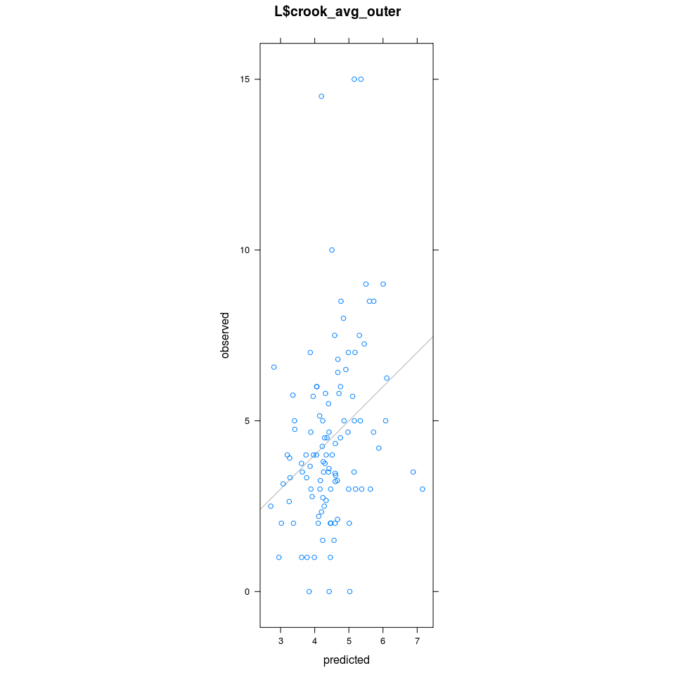

```
##
## Call:
## lm(formula = y ~ SWV + m_led, data = LL)
##
## Residuals:
##     Min      1Q  Median      3Q     Max
## -5.0260 -1.6590 -0.2693  1.2890 10.3030
##
## Coefficients:
##              Estimate Std. Error t value Pr(>|t|)
## (Intercept) 17.896113   4.321842   4.141 7.05e-05 ***
## SWV         -0.003170   0.001128  -2.809  0.00593 **
## m_led       -0.008465   0.003714  -2.280  0.02467 *
## ---
## Signif. codes:  0 '***' 0.001 '**' 0.01 '*' 0.05 '.' 0.1 ' ' 1
##
## Residual standard error: 2.638 on 104 degrees of freedom
## Multiple R-squared:  0.08801,    Adjusted R-squared:  0.07047
## F-statistic: 5.018 on 2 and 104 DF,  p-value: 0.008308
```

### 3.3.3 Bow

```r
  summary(m <- best.linear.model(L$bow_avg))
```

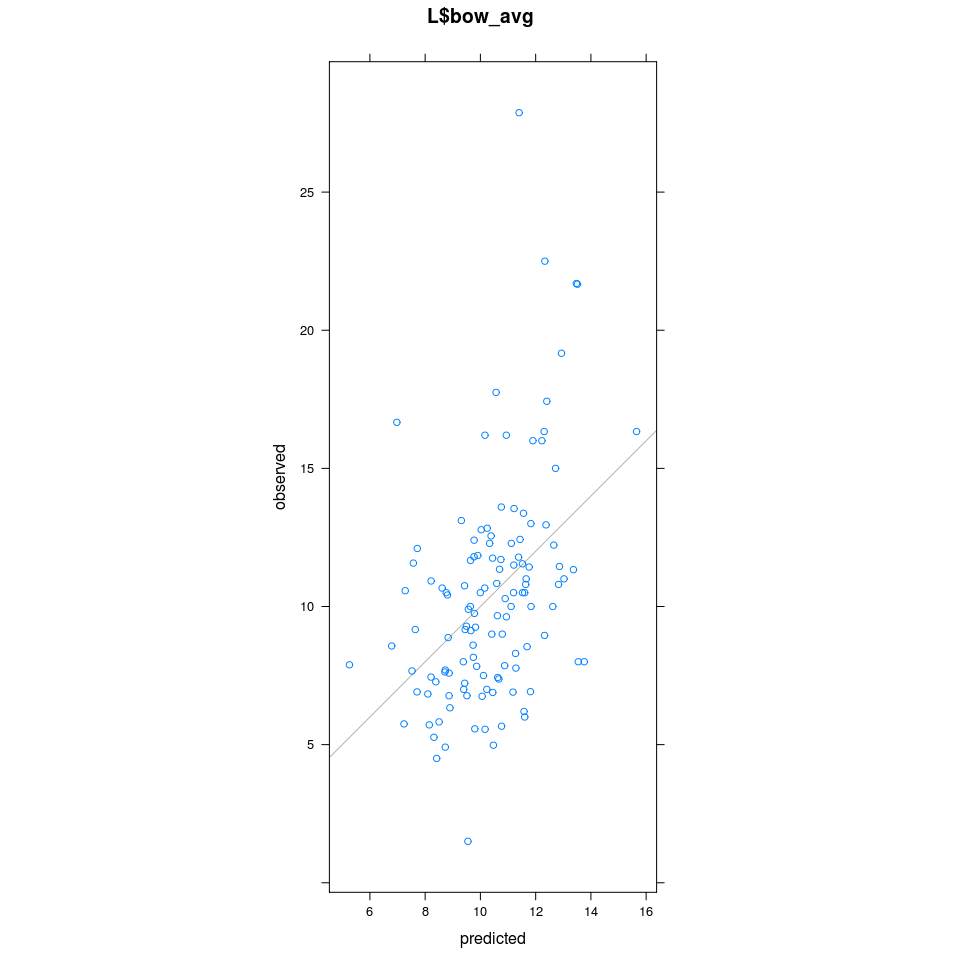

```
##
## Call:
## lm(formula = y ~ SWV + density + m_taper, data = LL)
##
## Residuals:
##     Min      1Q  Median      3Q     Max
## -8.0477 -2.3025 -0.5719  1.8777 16.4729
##
## Coefficients:
##              Estimate Std. Error t value Pr(>|t|)
## (Intercept) 50.130387   7.768906   6.453 2.48e-09 ***
## SWV         -0.006338   0.001486  -4.265 4.04e-05 ***
## density     -0.016751   0.005007  -3.345  0.00110 **
## m_taper     -0.344437   0.128428  -2.682  0.00836 **
## ---
## Signif. codes:  0 '***' 0.001 '**' 0.01 '*' 0.05 '.' 0.1 ' ' 1
##
## Residual standard error: 3.637 on 119 degrees of freedom
## Multiple R-squared:  0.1857, Adjusted R-squared:  0.1651
## F-statistic: 9.044 on 3 and 119 DF,  p-value: 1.925e-05
```

```r
  summary(m <- best.linear.model(L$bow_avg_inner))
```

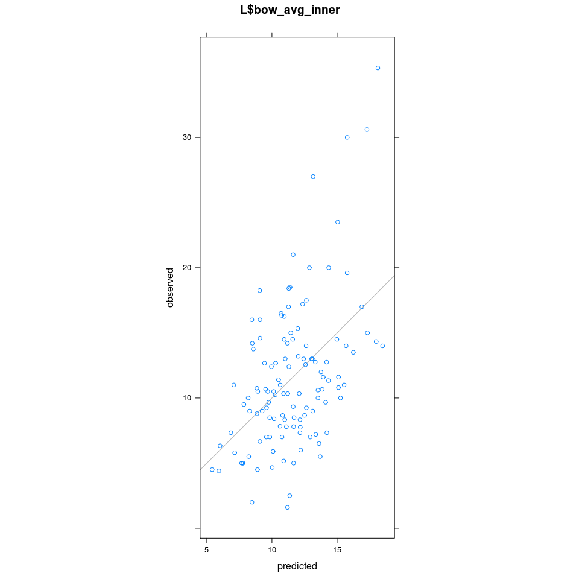

```
##
## Call:
## lm(formula = y ~ SWV + m_ovality + density + m_taper + m_a2 +
##     m_a1, data = LL)
##
## Residuals:
##    Min     1Q Median     3Q    Max
## -9.588 -3.326 -0.567  2.560 17.202
##
## Coefficients:
##               Estimate Std. Error t value Pr(>|t|)
## (Intercept)  5.375e+01  1.099e+01   4.891 3.35e-06 ***
## SWV         -8.798e-03  2.102e-03  -4.186 5.65e-05 ***
## m_ovality    1.686e+03  6.535e+02   2.580  0.01116 *
## density     -1.189e-02  6.972e-03  -1.706  0.09078 .
## m_taper     -5.683e+00  1.801e+00  -3.155  0.00205 **
## m_a2         1.152e+00  3.796e-01   3.035  0.00299 **
## m_a1         1.124e+00  3.784e-01   2.971  0.00363 **
## ---
## Signif. codes:  0 '***' 0.001 '**' 0.01 '*' 0.05 '.' 0.1 ' ' 1
##
## Residual standard error: 5.035 on 113 degrees of freedom
## Multiple R-squared:  0.2349, Adjusted R-squared:  0.1943
## F-statistic: 5.782 on 6 and 113 DF,  p-value: 2.798e-05
```

```r
  summary(m <- best.linear.model(L$bow_avg_outer))
```

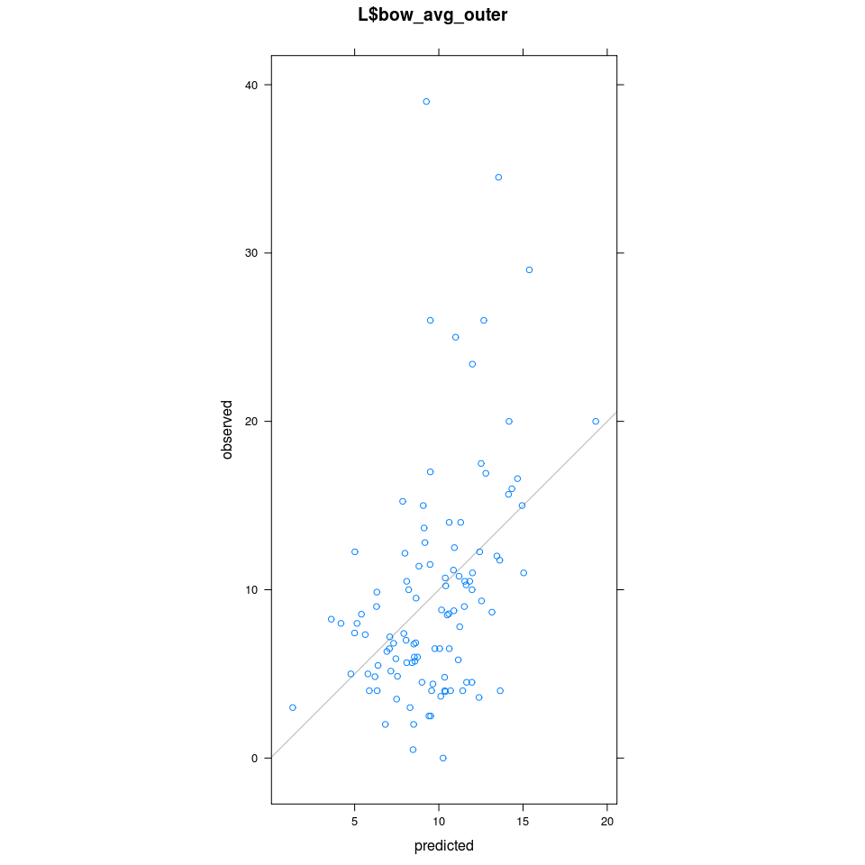

```
##
## Call:
## lm(formula = y ~ SWV + density + m_taper, data = LL)
##
## Residuals:
##     Min      1Q  Median      3Q     Max
## -10.252  -3.351  -1.038   2.422  29.742
##
## Coefficients:
##              Estimate Std. Error t value Pr(>|t|)
## (Intercept) 79.129663  14.626657   5.410 4.12e-07 ***
## SWV         -0.010528   0.002726  -3.862 0.000197 ***
## density     -0.031996   0.009811  -3.261 0.001505 **
## m_taper     -0.506055   0.223307  -2.266 0.025531 *
## ---
## Signif. codes:  0 '***' 0.001 '**' 0.01 '*' 0.05 '.' 0.1 ' ' 1
##
## Residual standard error: 6.205 on 103 degrees of freedom
## Multiple R-squared:  0.1841, Adjusted R-squared:  0.1603
## F-statistic: 7.746 on 3 and 103 DF,  p-value: 0.0001026
```

### 3.3.4 Outer c.f. Inner

Do logs with lousy inner boards also have lousy outer boards?

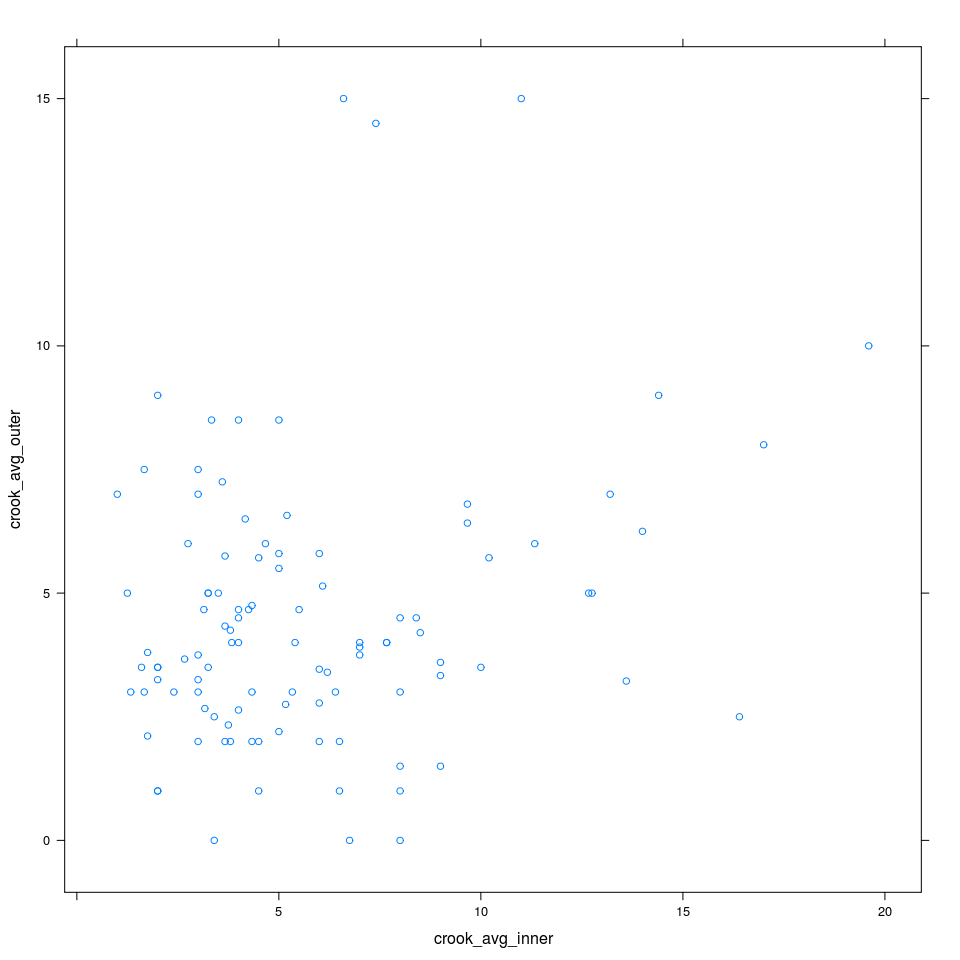

```r
xyplot(crook_avg_outer ~ crook_avg_inner, L)
```

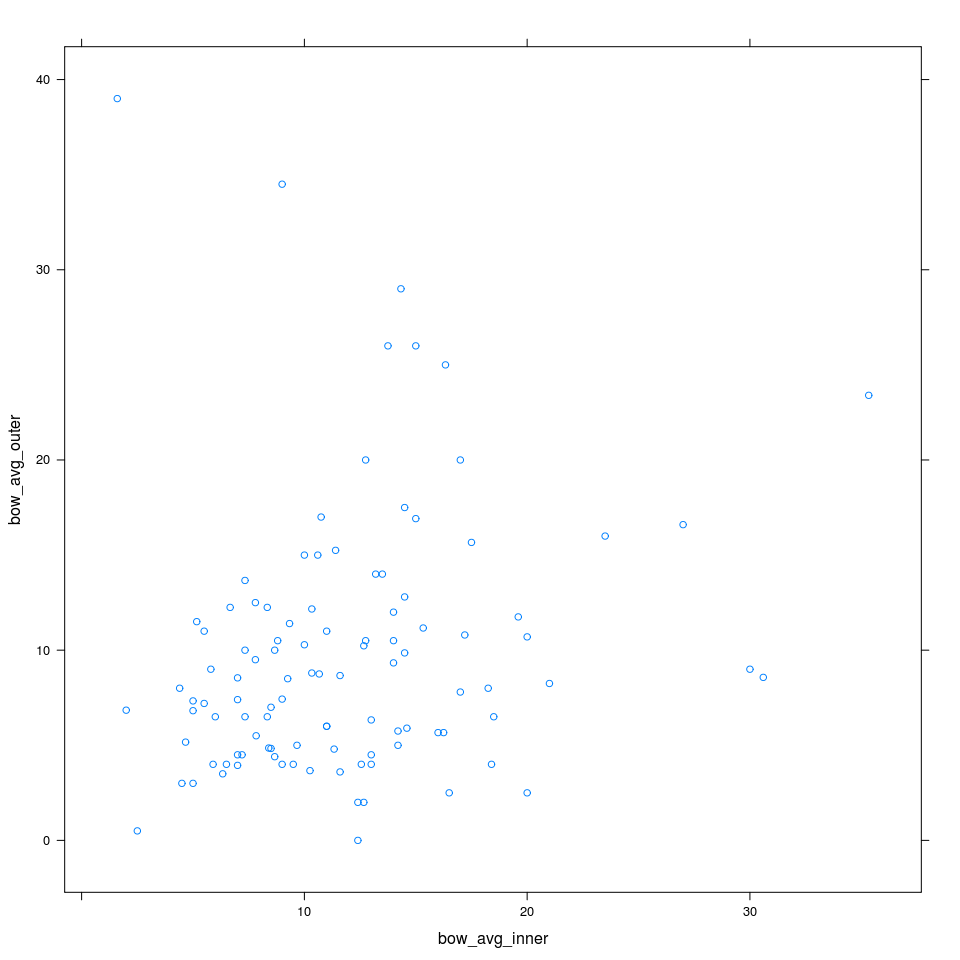

```r
xyplot(bow_avg_outer ~ bow_avg_inner, L)
```

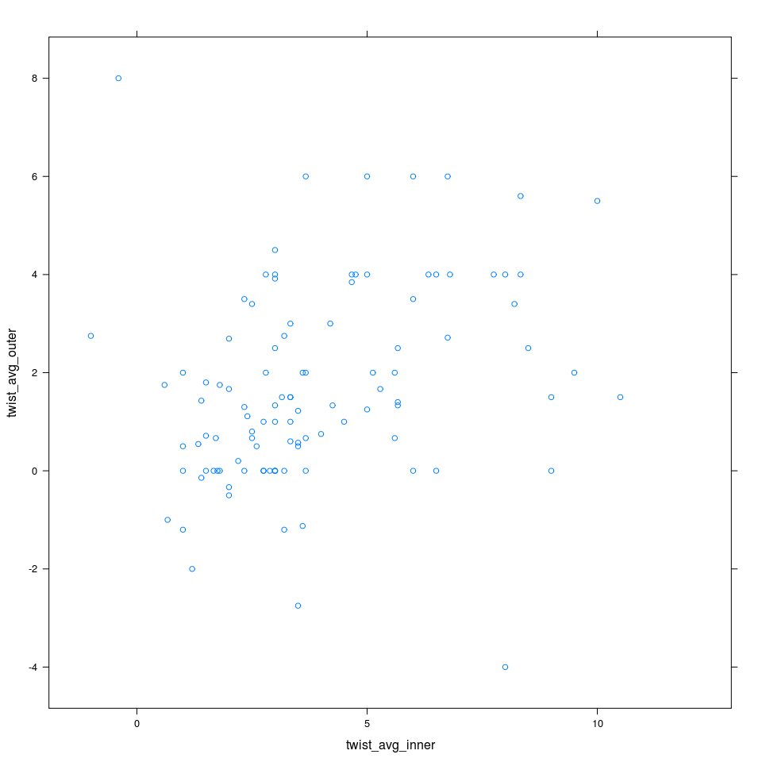

```r
xyplot(twist_avg_outer ~ twist_avg_inner, L)
```

No. Outer and Inner pretty much uncorrelated.

## 3.4 Reduced Datasets

If we look only at subsets of logs that are in some way ‘good’, do we get similar prediction models?

### 3.4.1 Marco’s CW-free logs

Fit models only to logs Marco identified as not appearing to contain significant CW based on log end imagery.

```r
both.ends.severe.cw = c(189, 210, 212, 222)
both.ends.moderate.cw = c(123, 135, 144, 159, 178, 188, 190, 208)
for (lmeas in log.quality.measures) {
  models <- cf.full(lmeas, idx.sub=!L$SWILogNumber%in%union(both.ends.severe.cw,both.ends.moderate.cw))
}
```

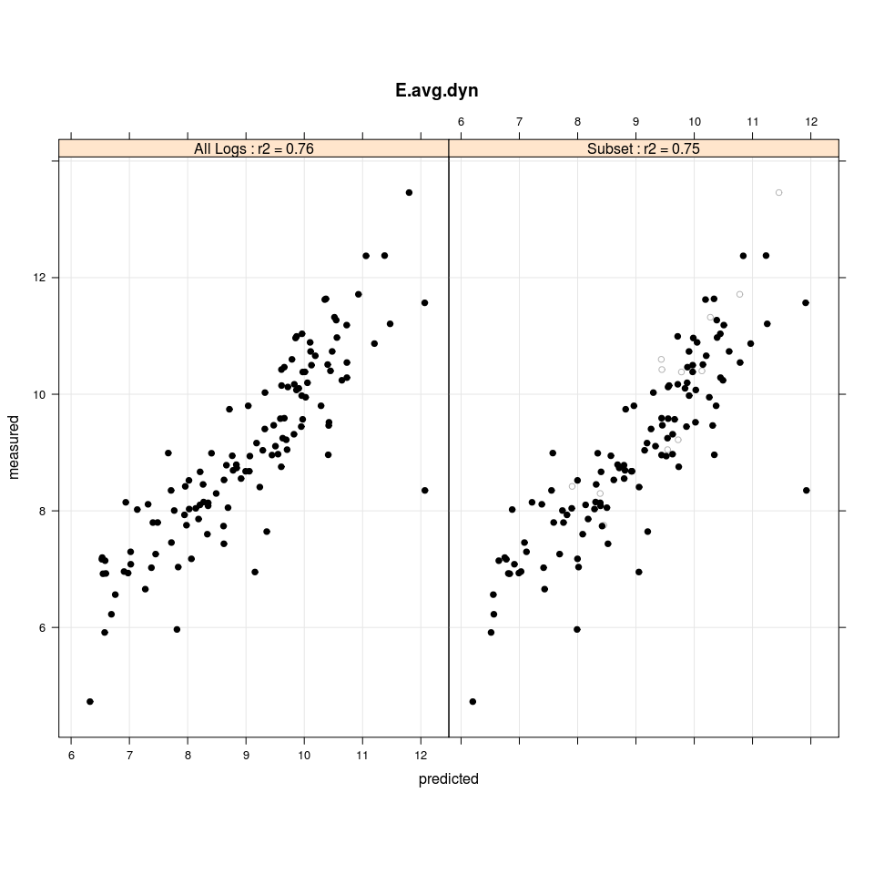

```
Call:
lm(formula = y ~ SWV + density + m_volume + m_whorliness + hw.vfrac +
    m_waist + m_a2 + weight, data = LL)

Residuals:
    Min      1Q  Median      3Q     Max
-3.7188 -0.3894 -0.0142  0.4668  1.6611

Coefficients:
               Estimate Std. Error t value Pr(>|t|)
(Intercept)  -1.481e+01  2.507e+00  -5.909 3.64e-08 ***
SWV           5.044e-03  3.339e-04  15.108  < 2e-16 ***
density       8.795e-03  2.283e-03   3.853 0.000194 ***
m_volume      8.452e+00  4.310e+00   1.961 0.052331 .
m_whorliness -9.294e-01  2.709e-01  -3.430 0.000840 ***
hw.vfrac     -3.476e+00  1.260e+00  -2.758 0.006782 **
m_waist       1.269e+01  4.630e+00   2.741 0.007107 **
m_a2         -1.329e-01  5.087e-02  -2.613 0.010186 *
weight       -6.934e-03  4.161e-03  -1.666 0.098377 .
---
Signif. codes:  0 '***' 0.001 '**' 0.01 '*' 0.05 '.' 0.1 ' ' 1

Residual standard error: 0.7937 on 114 degrees of freedom
Multiple R-squared:  0.7588,    Adjusted R-squared:  0.7419
F-statistic: 44.84 on 8 and 114 DF,  p-value: < 2.2e-16
```

```
Call:
lm(formula = y ~ SWV + density + m_volume + m_whorliness + m_waist +
    m_a2 + hw.vfrac + m_sweep2 + m_a0, data = LL)

Residuals:
    Min      1Q  Median      3Q     Max
-3.5739 -0.3175  0.0217  0.4540  1.5333

Coefficients:
               Estimate Std. Error t value Pr(>|t|)
(Intercept)  -1.047e+01  2.447e+00  -4.278 4.29e-05 ***
SWV           4.768e-03  3.652e-04  13.057  < 2e-16 ***
density       6.581e-03  1.932e-03   3.406 0.000946 ***
m_volume      5.065e+00  2.618e+00   1.934 0.055850 .
m_whorliness -6.711e-01  3.047e-01  -2.203 0.029878 *
m_waist       1.220e+01  4.461e+00   2.736 0.007347 **
m_a2         -1.260e-01  4.891e-02  -2.576 0.011452 *
hw.vfrac     -2.697e+00  1.305e+00  -2.067 0.041336 *
m_sweep2     -1.142e+00  7.638e-01  -1.495 0.138099
m_a0         -1.007e-02  6.810e-03  -1.478 0.142449
---
Signif. codes:  0 '***' 0.001 '**' 0.01 '*' 0.05 '.' 0.1 ' ' 1

Residual standard error: 0.7889 on 101 degrees of freedom
Multiple R-squared:  0.7525,    Adjusted R-squared:  0.7304
F-statistic: 34.11 on 9 and 101 DF,  p-value: < 2.2e-16
```

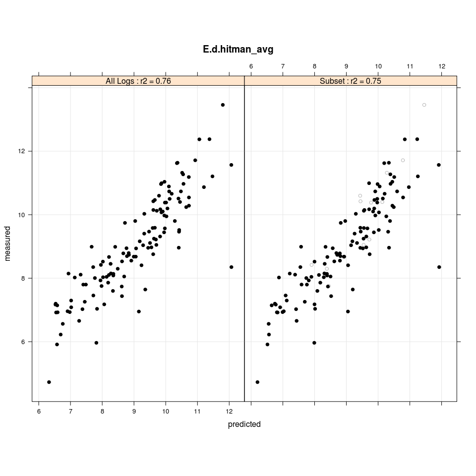

```
Call:
lm(formula = y ~ SWV + density + m_volume + m_whorliness + hw.vfrac +
    m_waist + m_a2 + weight, data = LL)

Residuals:
    Min      1Q  Median      3Q     Max
-3.7188 -0.3894 -0.0142  0.4668  1.6611

Coefficients:
               Estimate Std. Error t value Pr(>|t|)
(Intercept)  -1.481e+01  2.507e+00  -5.909 3.64e-08 ***
SWV           5.044e-03  3.339e-04  15.108  < 2e-16 ***
density       8.795e-03  2.283e-03   3.853 0.000194 ***
m_volume      8.452e+00  4.310e+00   1.961 0.052331 .
m_whorliness -9.294e-01  2.709e-01  -3.430 0.000840 ***
hw.vfrac     -3.476e+00  1.260e+00  -2.758 0.006782 **
m_waist       1.269e+01  4.630e+00   2.741 0.007107 **
m_a2         -1.329e-01  5.087e-02  -2.613 0.010186 *
weight       -6.934e-03  4.161e-03  -1.666 0.098377 .
---
Signif. codes:  0 '***' 0.001 '**' 0.01 '*' 0.05 '.' 0.1 ' ' 1

Residual standard error: 0.7937 on 114 degrees of freedom
Multiple R-squared:  0.7588,    Adjusted R-squared:  0.7419
F-statistic: 44.84 on 8 and 114 DF,  p-value: < 2.2e-16
```

```
Call:
lm(formula = y ~ SWV + density + m_volume + m_whorliness + m_waist +
    m_a2 + hw.vfrac + m_sweep2 + m_a0, data = LL)

Residuals:
    Min      1Q  Median      3Q     Max
-3.5739 -0.3175  0.0217  0.4540  1.5333

Coefficients:
               Estimate Std. Error t value Pr(>|t|)
(Intercept)  -1.047e+01  2.447e+00  -4.278 4.29e-05 ***
SWV           4.768e-03  3.652e-04  13.057  < 2e-16 ***
density       6.581e-03  1.932e-03   3.406 0.000946 ***
m_volume      5.065e+00  2.618e+00   1.934 0.055850 .
m_whorliness -6.711e-01  3.047e-01  -2.203 0.029878 *
m_waist       1.220e+01  4.461e+00   2.736 0.007347 **
m_a2         -1.260e-01  4.891e-02  -2.576 0.011452 *
hw.vfrac     -2.697e+00  1.305e+00  -2.067 0.041336 *
m_sweep2     -1.142e+00  7.638e-01  -1.495 0.138099
m_a0         -1.007e-02  6.810e-03  -1.478 0.142449
---
Signif. codes:  0 '***' 0.001 '**' 0.01 '*' 0.05 '.' 0.1 ' ' 1

Residual standard error: 0.7889 on 101 degrees of freedom
Multiple R-squared:  0.7525,    Adjusted R-squared:  0.7304
F-statistic: 34.11 on 9 and 101 DF,  p-value: < 2.2e-16
```

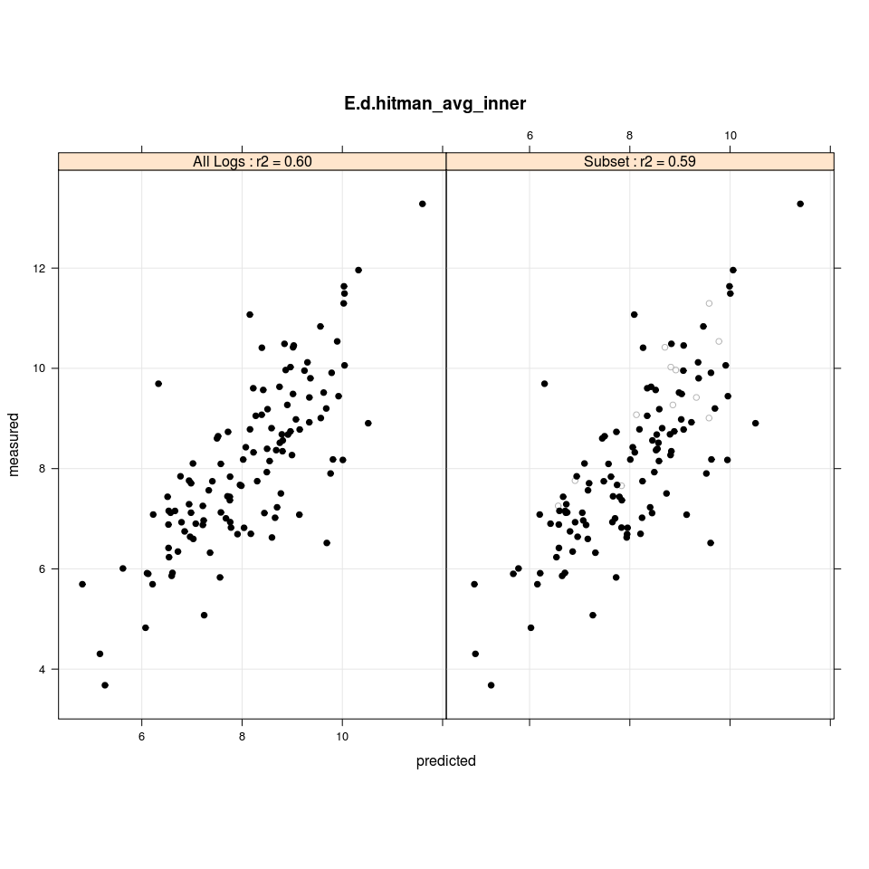

```
Call:
lm(formula = y ~ SWV + density + m_a0 + m_whorliness, data = LL)

Residuals:
    Min      1Q  Median      3Q     Max
-3.1729 -0.5000 -0.1065  0.6968  3.3610

Coefficients:
               Estimate Std. Error t value Pr(>|t|)
(Intercept)  -1.192e+01  2.354e+00  -5.063 1.60e-06 ***
SWV           3.599e-03  4.353e-04   8.268 2.82e-13 ***
density       1.150e-02  1.530e-03   7.513 1.41e-11 ***
m_a0         -5.816e-03  1.587e-03  -3.665 0.000377 ***
m_whorliness -1.122e+00  3.675e-01  -3.054 0.002809 **
---
Signif. codes:  0 '***' 0.001 '**' 0.01 '*' 0.05 '.' 0.1 ' ' 1

Residual standard error: 1.072 on 114 degrees of freedom
Multiple R-squared:  0.5955,    Adjusted R-squared:  0.5813
F-statistic: 41.96 on 4 and 114 DF,  p-value: < 2.2e-16
```

```
Call:
lm(formula = y ~ SWV + density + m_a0 + m_whorliness + m_ovality,
    data = LL)

Residuals:
    Min      1Q  Median      3Q     Max
-3.0947 -0.5504 -0.0438  0.5584  3.3936

Coefficients:
               Estimate Std. Error t value Pr(>|t|)
(Intercept)  -1.086e+01  2.500e+00  -4.343 3.36e-05 ***
SWV           3.464e-03  4.597e-04   7.536 2.14e-11 ***
density       1.089e-02  1.605e-03   6.785 8.06e-10 ***
m_a0         -6.062e-03  1.679e-03  -3.610 0.000478 ***
m_whorliness -1.029e+00  3.928e-01  -2.620 0.010145 *
m_ovality    -2.438e+02  1.536e+02  -1.587 0.115612
---
Signif. codes:  0 '***' 0.001 '**' 0.01 '*' 0.05 '.' 0.1 ' ' 1

Residual standard error: 1.086 on 101 degrees of freedom
Multiple R-squared:  0.5851,    Adjusted R-squared:  0.5646
F-statistic: 28.49 on 5 and 101 DF,  p-value: < 2.2e-16
```

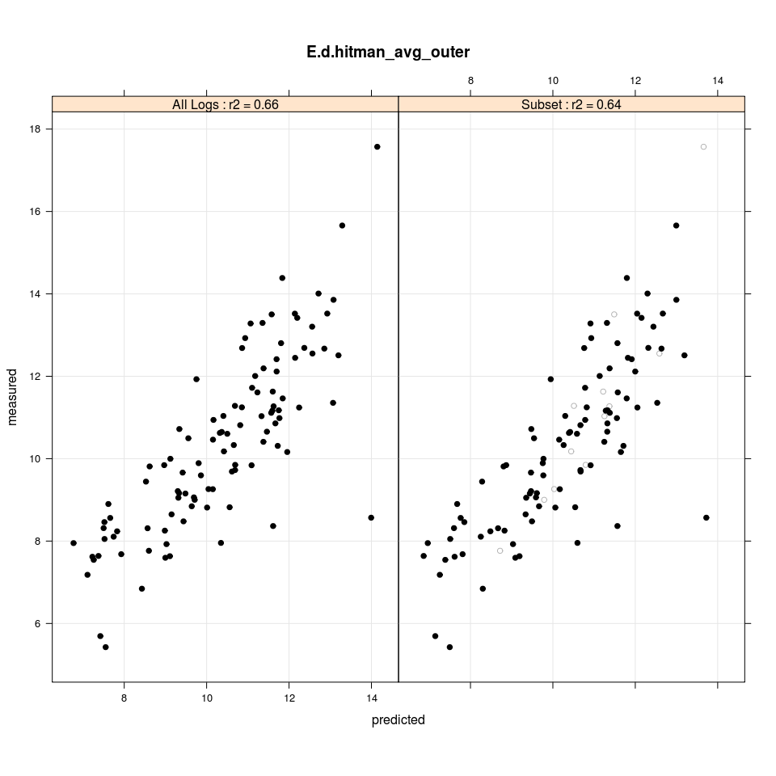

```
Call:
lm(formula = y ~ SWV + hw.vfrac + sweep.prod + m_a1 + m_ovality,
    data = LL)

Residuals:
    Min      1Q  Median      3Q     Max
-5.4250 -0.7854  0.0482  0.7849  3.4290

Coefficients:
              Estimate Std. Error t value Pr(>|t|)
(Intercept) -7.766e+00  1.927e+00  -4.031  0.00011 ***
SWV          6.280e-03  5.832e-04  10.768  < 2e-16 ***
hw.vfrac    -7.427e+00  1.351e+00  -5.499 3.04e-07 ***
sweep.prod  -1.545e+00  5.176e-01  -2.984  0.00359 **
m_a1        -1.233e-02  4.302e-03  -2.865  0.00510 **
m_ovality    3.087e+02  1.710e+02   1.805  0.07412 .
---
Signif. codes:  0 '***' 0.001 '**' 0.01 '*' 0.05 '.' 0.1 ' ' 1

Residual standard error: 1.287 on 98 degrees of freedom
Multiple R-squared:  0.6554,    Adjusted R-squared:  0.6379
F-statistic: 37.28 on 5 and 98 DF,  p-value: < 2.2e-16
```

```
Call:
lm(formula = y ~ SWV + density + sweep.prod + m_a1 + hw.vfrac +
    m_ovality, data = LL)

Residuals:
    Min      1Q  Median      3Q     Max
-5.1560 -0.6863  0.0343  0.8042  2.6647

Coefficients:
              Estimate Std. Error t value Pr(>|t|)
(Intercept) -1.139e+01  4.194e+00  -2.715  0.00804 **
SWV          5.770e-03  6.256e-04   9.224  1.9e-14 ***
density      4.724e-03  3.399e-03   1.390  0.16823
sweep.prod  -1.628e+00  5.467e-01  -2.978  0.00378 **
m_a1        -1.035e-02  4.434e-03  -2.335  0.02193 *
hw.vfrac    -4.051e+00  2.193e+00  -1.847  0.06817 .
m_ovality    3.212e+02  1.852e+02   1.735  0.08645 .
---
Signif. codes:  0 '***' 0.001 '**' 0.01 '*' 0.05 '.' 0.1 ' ' 1

Residual standard error: 1.278 on 85 degrees of freedom
Multiple R-squared:  0.6435,    Adjusted R-squared:  0.6183
F-statistic: 25.57 on 6 and 85 DF,  p-value: < 2.2e-16
```

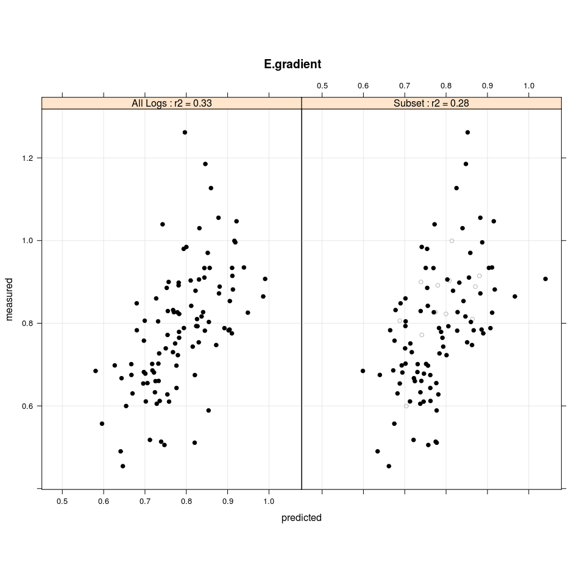

```
Call:
lm(formula = y ~ SWV + m_a0 + weight + sweep.prod + m_ovality +
    m_waist + m_whorliness + hw.vfrac + m_volume, data = LL)

Residuals:
     Min       1Q   Median       3Q      Max
-0.30929 -0.07260 -0.01550  0.07418  0.46518

Coefficients:
               Estimate Std. Error t value Pr(>|t|)
(Intercept)   1.593e+00  2.730e-01   5.835 8.17e-08 ***
SWV          -1.022e-04  6.432e-05  -1.589  0.11554
m_a0         -2.873e-03  1.498e-03  -1.918  0.05826 .
weight        1.824e-03  6.152e-04   2.965  0.00386 **
sweep.prod    1.494e-01  5.605e-02   2.666  0.00909 **
m_ovality    -4.085e+01  1.764e+01  -2.315  0.02283 *
m_waist      -9.980e-02  4.626e-02  -2.157  0.03363 *
m_whorliness -1.013e-01  5.049e-02  -2.006  0.04784 *
hw.vfrac      4.014e-01  1.986e-01   2.022  0.04615 *
m_volume     -9.624e-01  6.685e-01  -1.440  0.15342
---
Signif. codes:  0 '***' 0.001 '**' 0.01 '*' 0.05 '.' 0.1 ' ' 1

Residual standard error: 0.1306 on 91 degrees of freedom
Multiple R-squared:  0.3267,    Adjusted R-squared:  0.2601
F-statistic: 4.906 on 9 and 91 DF,  p-value: 2.309e-05
```

```
Call:
lm(formula = y ~ SWV + m_a0 + m_ovality + m_a1 + sweep.prod +
    m_whorliness, data = LL)

Residuals:
     Min       1Q   Median       3Q      Max
-0.26629 -0.09705 -0.01340  0.08638  0.40959

Coefficients:
               Estimate Std. Error t value Pr(>|t|)
(Intercept)   1.255e+00  2.648e-01   4.740 8.87e-06 ***
SWV          -9.189e-05  6.678e-05  -1.376  0.17260
m_a0         -5.244e-04  2.441e-04  -2.148  0.03463 *
m_ovality    -5.495e+01  2.016e+01  -2.726  0.00785 **
m_a1          1.245e-03  5.240e-04   2.375  0.01988 *
sweep.prod    1.389e-01  6.114e-02   2.271  0.02575 *
m_whorliness -9.449e-02  5.480e-02  -1.724  0.08842 .
---
Signif. codes:  0 '***' 0.001 '**' 0.01 '*' 0.05 '.' 0.1 ' ' 1

Residual standard error: 0.1379 on 82 degrees of freedom
Multiple R-squared:  0.2763,    Adjusted R-squared:  0.2233
F-statistic: 5.217 on 6 and 82 DF,  p-value: 0.0001364
```

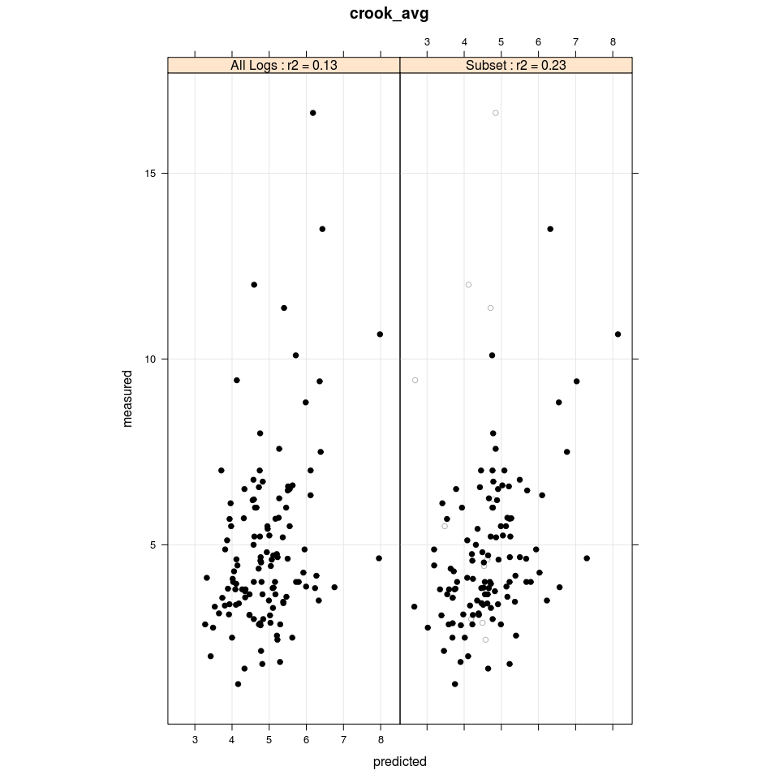

```
Call:
lm(formula = y ~ density + sweep.prod + m_a2, data = LL)

Residuals:
    Min      1Q  Median      3Q     Max
-3.4455 -1.4960 -0.3582  0.9658 10.4465

Coefficients:
             Estimate Std. Error t value Pr(>|t|)
(Intercept) 11.763314   2.899084   4.058  8.9e-05 ***
density     -0.007900   0.003032  -2.605   0.0104 *
sweep.prod   1.885969   0.839433   2.247   0.0265 *
m_a2        -0.012981   0.006966  -1.863   0.0649 .
---
Signif. codes:  0 '***' 0.001 '**' 0.01 '*' 0.05 '.' 0.1 ' ' 1

Residual standard error: 2.238 on 119 degrees of freedom
Multiple R-squared:  0.1293,    Adjusted R-squared:  0.1073
F-statistic: 5.888 on 3 and 119 DF,  p-value: 0.0008794
```

```
Call:
lm(formula = y ~ SWV + density + sweep.prod + m_ovality, data = LL)

Residuals:
    Min      1Q  Median      3Q     Max
-3.4305 -1.1562 -0.0191  0.9019  7.1817

Coefficients:
              Estimate Std. Error t value Pr(>|t|)
(Intercept)  2.032e+01  3.949e+00   5.147 1.23e-06 ***
SWV         -1.813e-03  7.203e-04  -2.517   0.0134 *
density     -1.063e-02  2.546e-03  -4.176 6.10e-05 ***
sweep.prod   1.206e+00  7.035e-01   1.715   0.0893 .
m_ovality   -3.550e+02  2.412e+02  -1.472   0.1441
---
Signif. codes:  0 '***' 0.001 '**' 0.01 '*' 0.05 '.' 0.1 ' ' 1

Residual standard error: 1.728 on 106 degrees of freedom
Multiple R-squared:  0.231, Adjusted R-squared:  0.202
F-statistic: 7.961 on 4 and 106 DF,  p-value: 1.19e-05
```

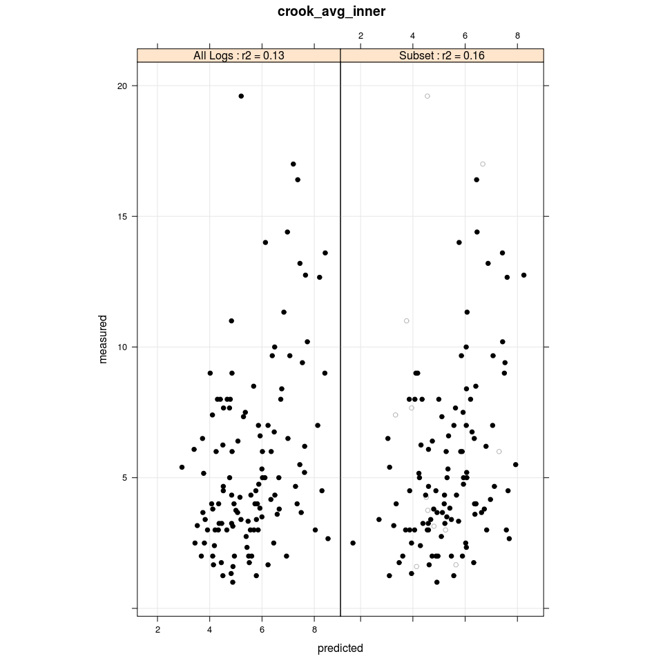

```
Call:
lm(formula = y ~ SWV + m_volume + weight, data = LL)

Residuals:
    Min      1Q  Median      3Q     Max
-5.8585 -2.2262 -0.9317  1.9024 14.3969

Coefficients:
             Estimate Std. Error t value Pr(>|t|)
(Intercept) 13.692827   4.710130   2.907 0.004371 **
SWV         -0.002810   0.001344  -2.091 0.038756 *
m_volume    40.881127  10.858042   3.765 0.000263 ***
weight      -0.036638   0.010143  -3.612 0.000450 ***
---
Signif. codes:  0 '***' 0.001 '**' 0.01 '*' 0.05 '.' 0.1 ' ' 1

Residual standard error: 3.388 on 116 degrees of freedom
Multiple R-squared:  0.1348,    Adjusted R-squared:  0.1124
F-statistic: 6.026 on 3 and 116 DF,  p-value: 0.0007514
```

```
Call:
lm(formula = y ~ SWV + density + m_led, data = LL)

Residuals:
    Min      1Q  Median      3Q     Max
-5.0202 -2.3430 -0.7896  1.6908  9.9622

Coefficients:
             Estimate Std. Error t value Pr(>|t|)
(Intercept) 25.464085   6.679669   3.812 0.000234 ***
SWV         -0.003110   0.001245  -2.498 0.014057 *
density     -0.013907   0.004337  -3.207 0.001784 **
m_led        0.009205   0.004313   2.135 0.035147 *
---
Signif. codes:  0 '***' 0.001 '**' 0.01 '*' 0.05 '.' 0.1 ' ' 1

Residual standard error: 3.015 on 104 degrees of freedom
Multiple R-squared:  0.158, Adjusted R-squared:  0.1337
F-statistic: 6.504 on 3 and 104 DF,  p-value: 0.0004466
```

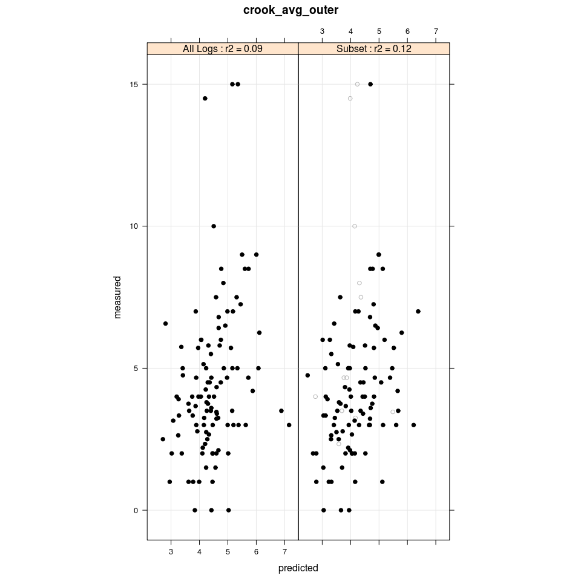

```
Call:
lm(formula = y ~ SWV + m_led, data = LL)

Residuals:
    Min      1Q  Median      3Q     Max
-5.0260 -1.6590 -0.2693  1.2890 10.3030

Coefficients:
             Estimate Std. Error t value Pr(>|t|)
(Intercept) 17.896113   4.321842   4.141 7.05e-05 ***
SWV         -0.003170   0.001128  -2.809  0.00593 **
m_led       -0.008465   0.003714  -2.280  0.02467 *
---
Signif. codes:  0 '***' 0.001 '**' 0.01 '*' 0.05 '.' 0.1 ' ' 1

Residual standard error: 2.638 on 104 degrees of freedom
Multiple R-squared:  0.08801,   Adjusted R-squared:  0.07047
F-statistic: 5.018 on 2 and 104 DF,  p-value: 0.008308
```

```
Call:
lm(formula = y ~ SWV + m_waist, data = LL)

Residuals:
   Min     1Q Median     3Q    Max
-4.117 -1.458 -0.410  1.079 10.302

Coefficients:
              Estimate Std. Error t value Pr(>|t|)
(Intercept) 13.8823417  3.0823416   4.504 1.95e-05 ***
SWV         -0.0029211  0.0009381  -3.114  0.00246 **
m_waist     -1.1009265  0.6672926  -1.650  0.10239
---
Signif. codes:  0 '***' 0.001 '**' 0.01 '*' 0.05 '.' 0.1 ' ' 1

Residual standard error: 2.211 on 92 degrees of freedom
Multiple R-squared:  0.1247,    Adjusted R-squared:  0.1057
F-statistic: 6.552 on 2 and 92 DF,  p-value: 0.002186
```

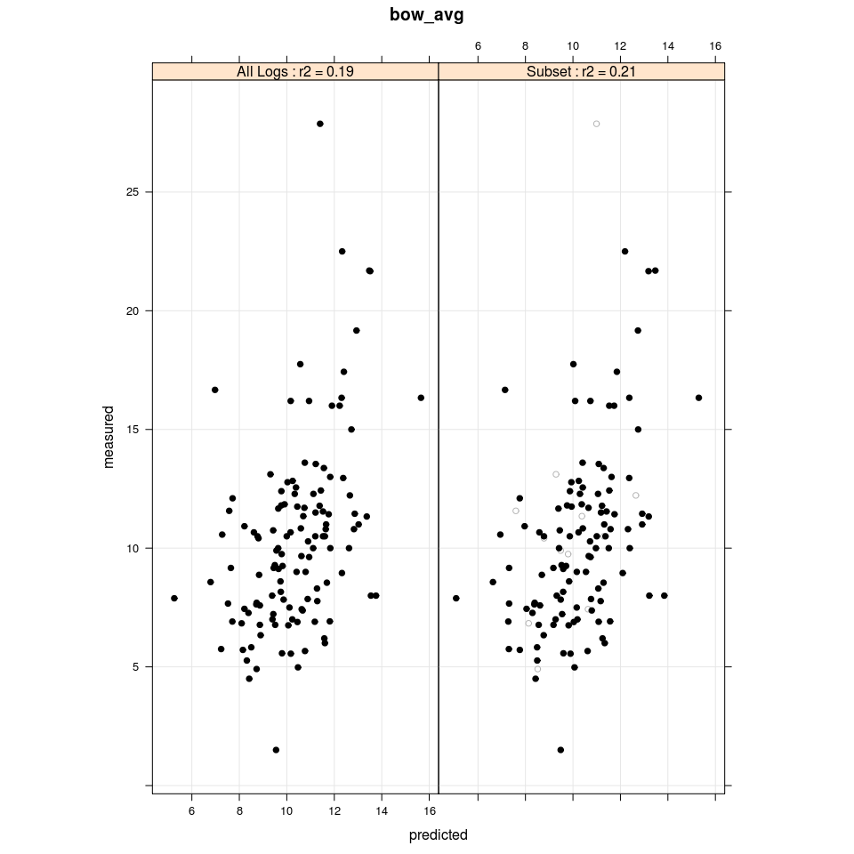

```
Call:
lm(formula = y ~ SWV + density + m_taper, data = LL)

Residuals:
    Min      1Q  Median      3Q     Max
-8.0477 -2.3025 -0.5719  1.8777 16.4729

Coefficients:
             Estimate Std. Error t value Pr(>|t|)
(Intercept) 50.130387   7.768906   6.453 2.48e-09 ***
SWV         -0.006338   0.001486  -4.265 4.04e-05 ***
density     -0.016751   0.005007  -3.345  0.00110 **
m_taper     -0.344437   0.128428  -2.682  0.00836 **
---
Signif. codes:  0 '***' 0.001 '**' 0.01 '*' 0.05 '.' 0.1 ' ' 1

Residual standard error: 3.637 on 119 degrees of freedom
Multiple R-squared:  0.1857,    Adjusted R-squared:  0.1651
F-statistic: 9.044 on 3 and 119 DF,  p-value: 1.925e-05
```

```
Call:
lm(formula = y ~ SWV + m_taper + density, data = LL)

Residuals:
    Min      1Q  Median      3Q     Max
-7.9845 -2.2948 -0.4606  1.9663 10.3078

Coefficients:
             Estimate Std. Error t value Pr(>|t|)
(Intercept) 48.551065   7.570629   6.413 3.96e-09 ***
SWV         -0.006247   0.001435  -4.352 3.10e-05 ***
m_taper     -0.397326   0.124624  -3.188  0.00188 **
density     -0.015006   0.004846  -3.096  0.00250 **
---
Signif. codes:  0 '***' 0.001 '**' 0.01 '*' 0.05 '.' 0.1 ' ' 1

Residual standard error: 3.399 on 107 degrees of freedom
Multiple R-squared:  0.2081,    Adjusted R-squared:  0.1859
F-statistic: 9.374 on 3 and 107 DF,  p-value: 1.484e-05
```

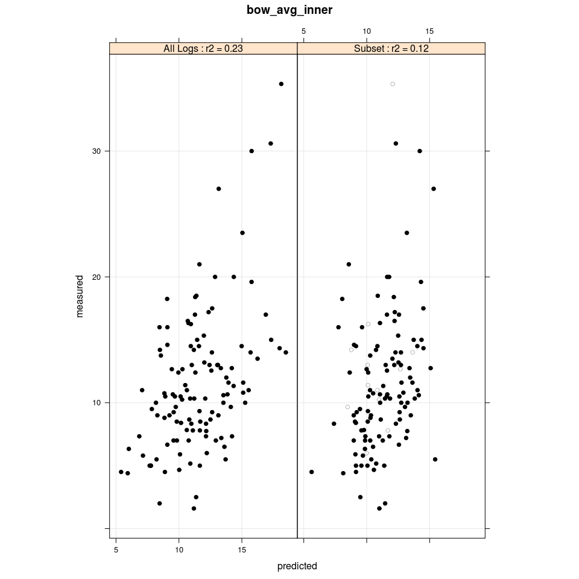

```
Call:
lm(formula = y ~ SWV + m_ovality + density + m_taper + m_a2 +
    m_a1, data = LL)

Residuals:
   Min     1Q Median     3Q    Max
-9.588 -3.326 -0.567  2.560 17.202

Coefficients:
              Estimate Std. Error t value Pr(>|t|)
(Intercept)  5.375e+01  1.099e+01   4.891 3.35e-06 ***
SWV         -8.798e-03  2.102e-03  -4.186 5.65e-05 ***
m_ovality    1.686e+03  6.535e+02   2.580  0.01116 *
density     -1.189e-02  6.972e-03  -1.706  0.09078 .
m_taper     -5.683e+00  1.801e+00  -3.155  0.00205 **
m_a2         1.152e+00  3.796e-01   3.035  0.00299 **
m_a1         1.124e+00  3.784e-01   2.971  0.00363 **
---
Signif. codes:  0 '***' 0.001 '**' 0.01 '*' 0.05 '.' 0.1 ' ' 1

Residual standard error: 5.035 on 113 degrees of freedom
Multiple R-squared:  0.2349,    Adjusted R-squared:  0.1943
F-statistic: 5.782 on 6 and 113 DF,  p-value: 2.798e-05
```

```
Call:
lm(formula = y ~ SWV + m_taper + density, data = LL)

Residuals:
   Min     1Q Median     3Q    Max
-9.940 -3.403 -1.019  2.381 18.284

Coefficients:
             Estimate Std. Error t value Pr(>|t|)
(Intercept) 51.382178  11.420289   4.499 1.78e-05 ***
SWV         -0.008108   0.002159  -3.756 0.000285 ***
m_taper     -0.327377   0.189276  -1.730 0.086664 .
density     -0.011032   0.007287  -1.514 0.133050
---
Signif. codes:  0 '***' 0.001 '**' 0.01 '*' 0.05 '.' 0.1 ' ' 1

Residual standard error: 5.095 on 104 degrees of freedom
Multiple R-squared:  0.125, Adjusted R-squared:  0.09974
F-statistic: 4.952 on 3 and 104 DF,  p-value: 0.002973
```

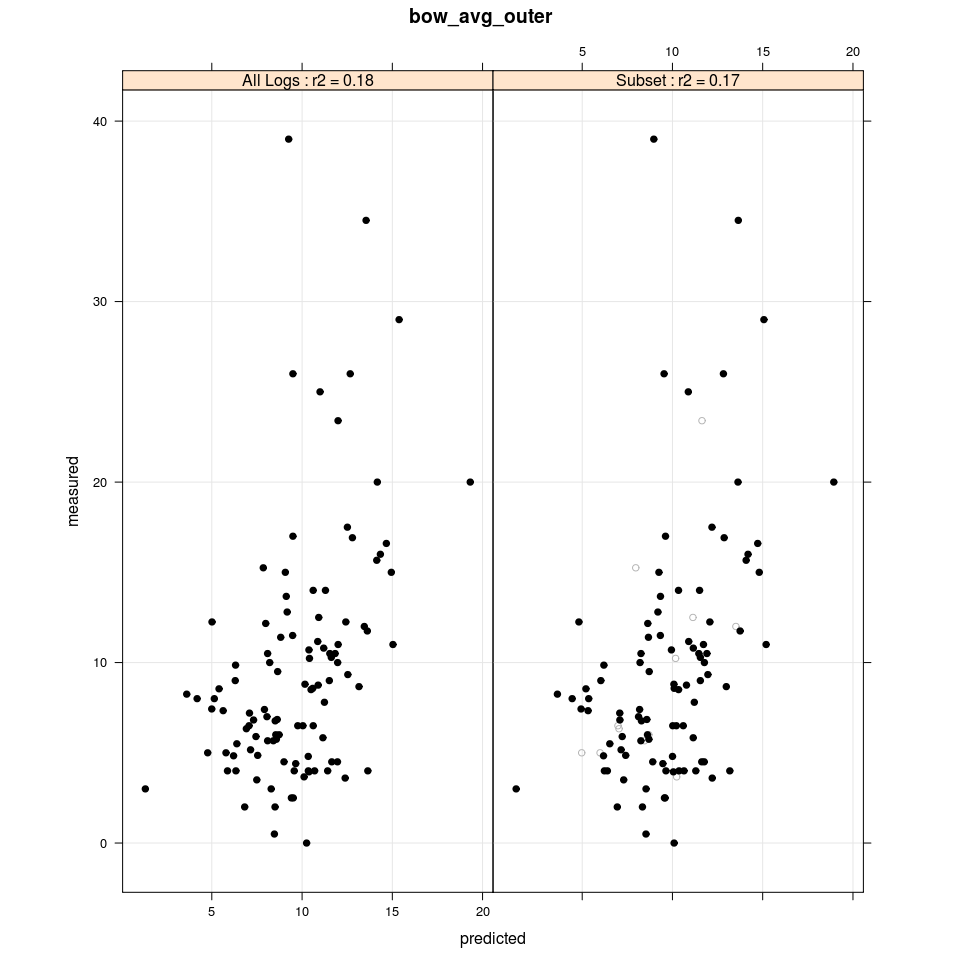

```
Call:
lm(formula = y ~ SWV + density + m_taper, data = LL)

Residuals:
    Min      1Q  Median      3Q     Max
-10.252  -3.351  -1.038   2.422  29.742

Coefficients:
             Estimate Std. Error t value Pr(>|t|)
(Intercept) 79.129663  14.626657   5.410 4.12e-07 ***
SWV         -0.010528   0.002726  -3.862 0.000197 ***
density     -0.031996   0.009811  -3.261 0.001505 **
m_taper     -0.506055   0.223307  -2.266 0.025531 *
---
Signif. codes:  0 '***' 0.001 '**' 0.01 '*' 0.05 '.' 0.1 ' ' 1

Residual standard error: 6.205 on 103 degrees of freedom
Multiple R-squared:  0.1841,    Adjusted R-squared:  0.1603
F-statistic: 7.746 on 3 and 103 DF,  p-value: 0.0001026
```

```
Call:
lm(formula = y ~ SWV + density + m_taper, data = LL)

Residuals:
    Min      1Q  Median      3Q     Max
-10.092  -3.756  -1.261   2.495  30.034

Coefficients:
             Estimate Std. Error t value Pr(>|t|)
(Intercept) 76.685764  15.857936   4.836 5.37e-06 ***
SWV         -0.010301   0.002924  -3.523  0.00067 ***
density     -0.029706   0.010557  -2.814  0.00600 **
m_taper     -0.557956   0.239664  -2.328  0.02212 *
---
Signif. codes:  0 '***' 0.001 '**' 0.01 '*' 0.05 '.' 0.1 ' ' 1

Residual standard error: 6.389 on 91 degrees of freedom
Multiple R-squared:  0.1738,    Adjusted R-squared:  0.1465
F-statistic: 6.379 on 3 and 91 DF,  p-value: 0.0005678
```

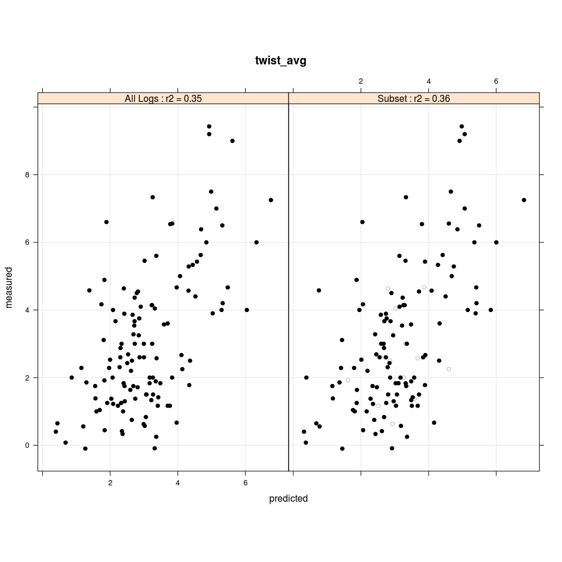

```
Call:
lm(formula = y ~ SWV + m_led + density + m_sweep1, data = LL)

Residuals:
    Min      1Q  Median      3Q     Max
-3.4066 -1.2787 -0.0760  0.9479  4.7106

Coefficients:
              Estimate Std. Error t value Pr(>|t|)
(Intercept) 15.4492981  3.6590429   4.222 4.78e-05 ***
SWV         -0.0037534  0.0006806  -5.515 2.09e-07 ***
m_led       -0.0134794  0.0022060  -6.110 1.32e-08 ***
density      0.0055963  0.0023843   2.347   0.0206 *
m_sweep1    -0.4608379  0.2696113  -1.709   0.0900 .
---
Signif. codes:  0 '***' 0.001 '**' 0.01 '*' 0.05 '.' 0.1 ' ' 1

Residual standard error: 1.715 on 118 degrees of freedom
Multiple R-squared:  0.3499,    Adjusted R-squared:  0.3278
F-statistic: 15.88 on 4 and 118 DF,  p-value: 2.005e-10
```

```
Call:
lm(formula = y ~ SWV + m_led + density + m_waist, data = LL)

Residuals:
    Min      1Q  Median      3Q     Max
-3.4961 -1.2907 -0.0032  0.9639  4.5572

Coefficients:
              Estimate Std. Error t value Pr(>|t|)
(Intercept) 12.9667427  3.9250009   3.304   0.0013 **
SWV         -0.0033431  0.0007334  -4.558 1.39e-05 ***
m_led       -0.0129257  0.0025281  -5.113 1.42e-06 ***
density      0.0061041  0.0025141   2.428   0.0169 *
m_waist     -0.8263980  0.5543254  -1.491   0.1390
---
Signif. codes:  0 '***' 0.001 '**' 0.01 '*' 0.05 '.' 0.1 ' ' 1

Residual standard error: 1.753 on 106 degrees of freedom
Multiple R-squared:  0.3634,    Adjusted R-squared:  0.3394
F-statistic: 15.13 on 4 and 106 DF,  p-value: 8.167e-10
```

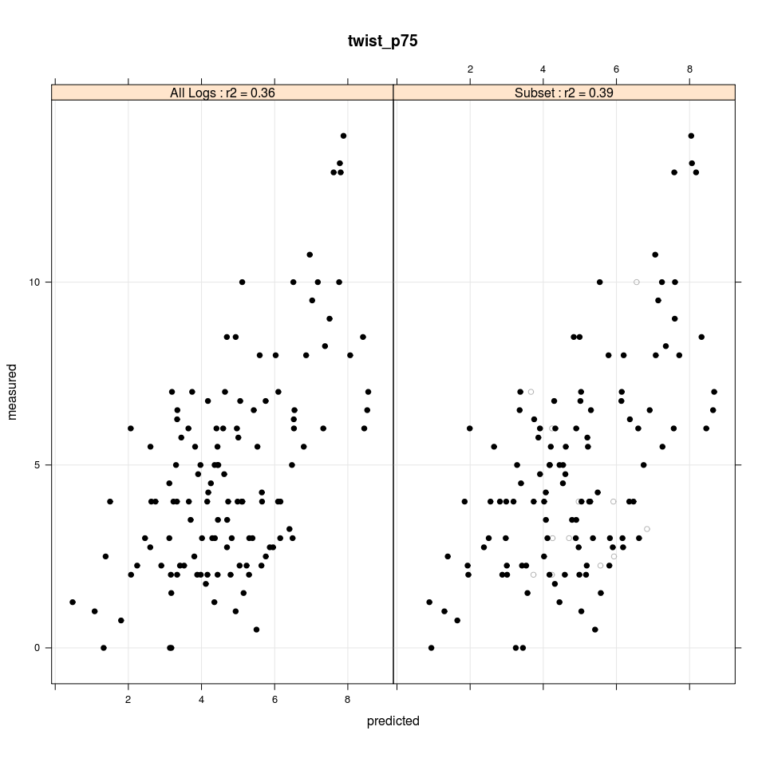

```
Call:
lm(formula = y ~ SWV + m_led + density + m_a0 + m_sweep1, data = LL)

Residuals:
    Min      1Q  Median      3Q     Max
-5.0033 -1.6639 -0.0643  1.3943  6.1180

Coefficients:
              Estimate Std. Error t value Pr(>|t|)
(Intercept) 15.8020819  5.1682682   3.058 0.002766 **
SWV         -0.0042191  0.0009682  -4.358 2.84e-05 ***
m_led       -0.0582205  0.0171397  -3.397 0.000932 ***
density      0.0120244  0.0032843   3.661 0.000378 ***
m_a0         0.0419754  0.0178312   2.354 0.020237 *
m_sweep1    -0.7225779  0.3724343  -1.940 0.054768 .
---
Signif. codes:  0 '***' 0.001 '**' 0.01 '*' 0.05 '.' 0.1 ' ' 1

Residual standard error: 2.363 on 117 degrees of freedom
Multiple R-squared:  0.3614,    Adjusted R-squared:  0.3341
F-statistic: 13.24 on 5 and 117 DF,  p-value: 3.178e-10
```

```
Call:
lm(formula = y ~ SWV + m_led + density + m_taper + m_sweep1,
    data = LL)

Residuals:
   Min     1Q Median     3Q    Max
-4.916 -1.708  0.173  1.350  5.956

Coefficients:
             Estimate Std. Error t value Pr(>|t|)
(Intercept) 14.138408   5.421189   2.608 0.010434 *
SWV         -0.003843   0.001006  -3.820 0.000226 ***
m_led       -0.016962   0.003277  -5.175  1.1e-06 ***
density      0.013002   0.003395   3.829 0.000219 ***
m_taper     -0.223891   0.091147  -2.456 0.015674 *
m_sweep1    -0.615403   0.396020  -1.554 0.123201
---
Signif. codes:  0 '***' 0.001 '**' 0.01 '*' 0.05 '.' 0.1 ' ' 1

Residual standard error: 2.352 on 105 degrees of freedom
Multiple R-squared:  0.3894,    Adjusted R-squared:  0.3603
F-statistic: 13.39 on 5 and 105 DF,  p-value: 4.249e-10
```

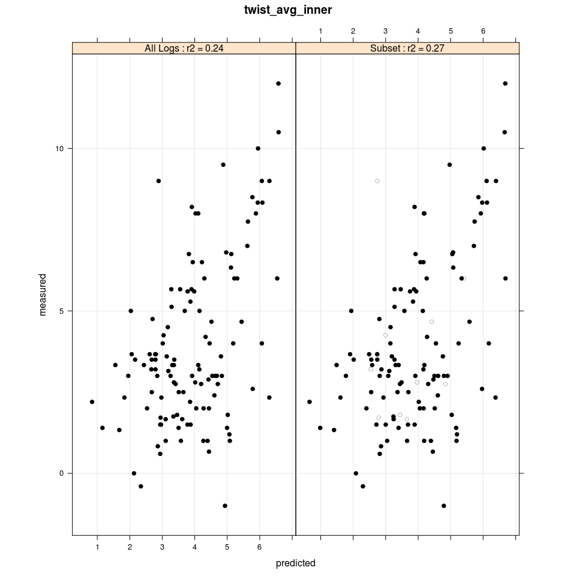

```
Call:
lm(formula = y ~ SWV + m_led + m_sweep1 + m_a0 + density + hw.vfrac,
    data = LL)

Residuals:
    Min      1Q  Median      3Q     Max
-5.9305 -1.6457 -0.0305  1.6103  6.1112

Coefficients:
              Estimate Std. Error t value Pr(>|t|)
(Intercept)  9.5224201  6.3441266   1.501  0.13615
SWV         -0.0041088  0.0009687  -4.242 4.56e-05 ***
m_led       -0.0467020  0.0167577  -2.787  0.00624 **
m_sweep1    -0.9216160  0.3666507  -2.514  0.01336 *
m_a0         0.0388637  0.0174861   2.223  0.02824 *
density      0.0129157  0.0052691   2.451  0.01577 *
hw.vfrac     6.0643018  3.4998425   1.733  0.08587 .
---
Signif. codes:  0 '***' 0.001 '**' 0.01 '*' 0.05 '.' 0.1 ' ' 1

Residual standard error: 2.275 on 113 degrees of freedom
Multiple R-squared:  0.2379,    Adjusted R-squared:  0.1974
F-statistic: 5.878 on 6 and 113 DF,  p-value: 2.3e-05
```

```
Call:
lm(formula = y ~ SWV + m_led + m_sweep1 + m_a0 + density + hw.vfrac,
    data = LL)

Residuals:
    Min      1Q  Median      3Q     Max
-5.7892 -1.6613 -0.0137  1.7291  5.3184

Coefficients:
             Estimate Std. Error t value Pr(>|t|)
(Intercept) 10.045248   6.474466   1.552  0.12391
SWV         -0.004257   0.001020  -4.174 6.36e-05 ***
m_led       -0.049979   0.017402  -2.872  0.00497 **
m_sweep1    -1.007637   0.396499  -2.541  0.01256 *
m_a0         0.041252   0.018054   2.285  0.02441 *
density      0.013262   0.005370   2.470  0.01521 *
hw.vfrac     6.724613   3.631540   1.852  0.06699 .
---
Signif. codes:  0 '***' 0.001 '**' 0.01 '*' 0.05 '.' 0.1 ' ' 1

Residual standard error: 2.285 on 101 degrees of freedom
Multiple R-squared:  0.2651,    Adjusted R-squared:  0.2215
F-statistic: 6.073 on 6 and 101 DF,  p-value: 1.853e-05
```

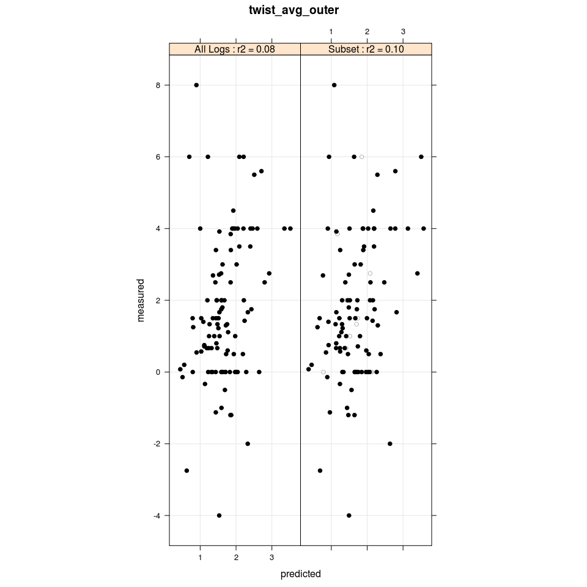

```
Call:
lm(formula = y ~ SWV + m_volume, data = LL)

Residuals:
    Min      1Q  Median      3Q     Max
-5.5305 -1.2237 -0.2467  1.0901  7.1053

Coefficients:
             Estimate Std. Error t value Pr(>|t|)
(Intercept) 10.041449   2.910553   3.450 0.000811 ***
SWV         -0.002250   0.000829  -2.714 0.007787 **
m_volume    -2.306404   1.087121  -2.122 0.036250 *
---
Signif. codes:  0 '***' 0.001 '**' 0.01 '*' 0.05 '.' 0.1 ' ' 1

Residual standard error: 1.937 on 104 degrees of freedom
Multiple R-squared:  0.08063,   Adjusted R-squared:  0.06294
F-statistic:  4.56 on 2 and 104 DF,  p-value: 0.01264
```

```
Call:
lm(formula = y ~ SWV + m_sed + sweep.prod, data = LL)

Residuals:
    Min      1Q  Median      3Q     Max
-5.4924 -1.3231 -0.1695  1.2001  6.9185

Coefficients:
              Estimate Std. Error t value Pr(>|t|)
(Intercept)  8.2486929  3.3202654   2.484   0.0148 *
SWV         -0.0015261  0.0008823  -1.730   0.0871 .
m_sed       -0.0063640  0.0029575  -2.152   0.0341 *
sweep.prod   1.2614083  0.8073831   1.562   0.1217
---
Signif. codes:  0 '***' 0.001 '**' 0.01 '*' 0.05 '.' 0.1 ' ' 1

Residual standard error: 1.956 on 91 degrees of freedom
Multiple R-squared:  0.1003,    Adjusted R-squared:  0.07059
F-statistic:  3.38 on 3 and 91 DF,  p-value: 0.02163
```